# PSC article analysis Q1 - CZECH

##### pre_ltx vs post_ltx

```r
group <- c("pre_ltx","post_ltx")
comparison_name <- paste0(group[1], " vs ",group[2])
```

**linDA**

```r
# prepare the data
linda_data <- binomial_prep(ileum_phylum_tab,
                            ileum_phylum_taxa_tab,
                            ileum_metadata,
                            group, usage="linDA")
```

```
## Removing 2 ASV(s)
```

```r
filt_ileum_uni_data <- linda_data[[1]]
filt_ileum_uni_taxa <- linda_data[[2]]
filt_ileum_uni_metadata <- linda_data[[3]]

# fit the model
linda.obj <- linda(filt_ileum_uni_data,
                   filt_ileum_uni_metadata,
                   formula = '~ Group')
```

```
## 0  features are filtered!
## The filtered data has  126  samples and  10  features will be tested!
## Imputation approach is used.
## Fit linear models ...
## Completed.
```

```r
linda.output <- linda.obj$output
linda.output <- linda_renaming(linda.output, group)

# save the results
group1 <- paste0(group[1], " vs ","Group",group[2])

for (grp in c(group1)){
  raw_linda_results_phylum[[segment]][[grp]] <-
    rawlinda.df(linda.output,
                grp,
                filt_ileum_uni_data,
                filt_ileum_uni_taxa)

  linda_results_phylum[[segment]][[grp]] <-
    linda.df(linda.output,
             grp,
             filt_ileum_uni_data,
             filt_ileum_uni_taxa)
}
```

```r
# volcano plot
volcano_1 <- volcano_plot_linda(linda.output,
                                group1,
                                taxa_table = filt_ileum_uni_taxa) +
            ggtitle(comparison_name)
```

```
## Using Phylum for naming
```

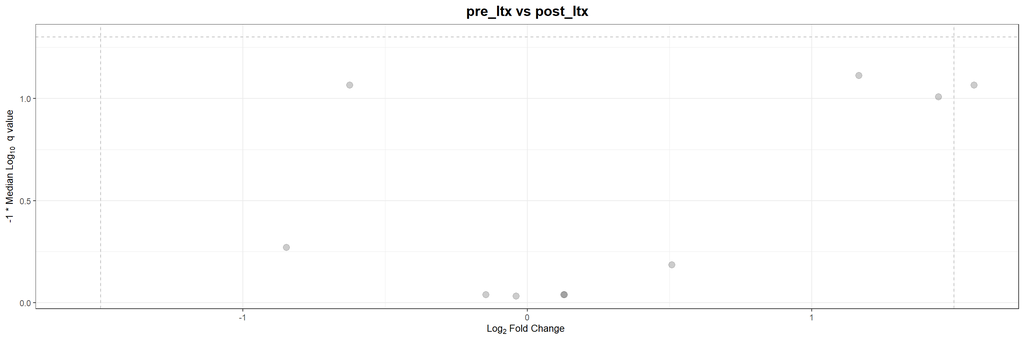

```r
volcano <- ggarrange(volcano_1)
volcano
```

**MaAsLin2**

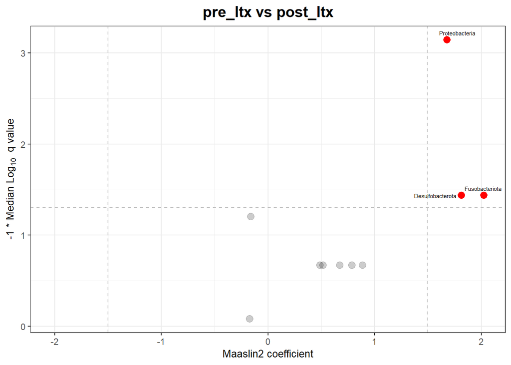

```r
volcano1 <- volcano_plot_maaslin(fit_data,filt_ileum_uni_taxa) +
            ggtitle(comparison_name)

volcano <- ggarrange(volcano1)
volcano
```

**Group - Intersection**

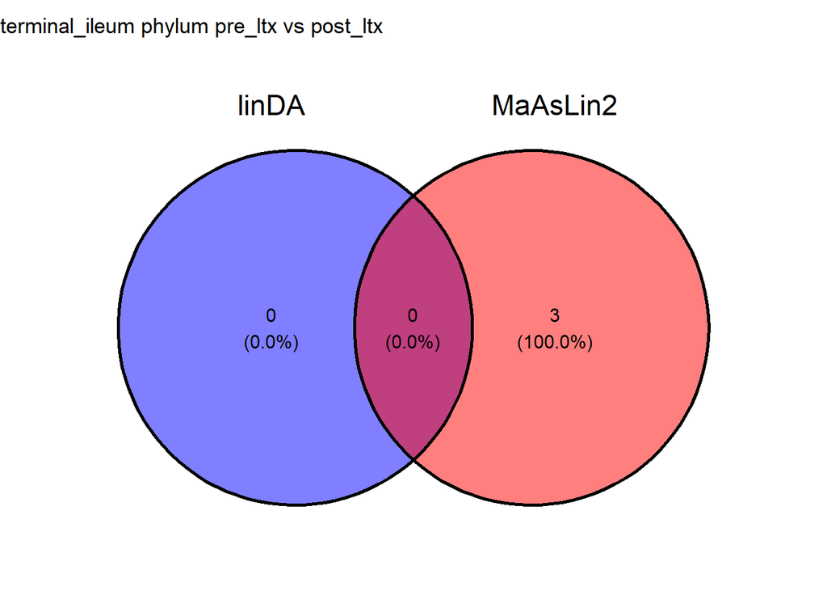

```r
intersection_results <- group_intersection(group, list_intersections, list_venns,
                                           linda.output, fit_data,
                                           raw_linda_results_phylum,
                                           segment = segment,
                                           level=level)

list_intersections <- intersection_results[[1]]
list_venns <- intersection_results[[2]]
venn <- intersection_results[[3]]

# show the results
venn
```

**Basic statistics**

```r
uni_df <-  merge(basic_univariate_statistics(linda_data,group),
                 raw_linda_results_phylum[[segment]][[group1]],
                 by="SeqID",all=TRUE)
```

```
## [1] "pre_ltx"
## [1] "post_ltx"
## [1] "pre_ltx"
## [1] "post_ltx"
```

```r
uni_df[["final_sig"]] <- uni_df$SeqID %in% list_intersections[[paste(segment,level,comparison_name)]][["SeqID"]]
uni_statistics[[segment]][[paste(level,comparison_name)]] <- uni_df

# for comparison
new_name <- paste(level,comparison_name)
addWorksheet(supplements_wb, sheetName = new_name)
writeData(supplements_wb, sheet = new_name, uni_df, rowNames=FALSE)
```

##### post_ltx vs healthy

```r
group <- c("healthy","post_ltx")
comparison_name <- paste0(group[1], " vs ",group[2])
```

**linDA**

```r
# prepare the data
linda_data <- binomial_prep(ileum_phylum_tab,
                            ileum_phylum_taxa_tab,
                            ileum_metadata,
                            group, usage="linDA")

filt_ileum_uni_data <- linda_data[[1]]
filt_ileum_uni_taxa <- linda_data[[2]]
filt_ileum_uni_metadata <- linda_data[[3]]

# fit the model
linda.obj <- linda(filt_ileum_uni_data,
                   filt_ileum_uni_metadata,
                   formula = '~ Group')
```

```
## 0  features are filtered!
## The filtered data has  139  samples and  10  features will be tested!
## Imputation approach is used.
## Fit linear models ...
## Completed.
```

```r
linda.output <- linda.obj$output
linda.output <- linda_renaming(linda.output, group)

# save the results
group1 <- paste0(group[1], " vs ","Group",group[2])

for (grp in c(group1)){
  raw_linda_results_phylum[[segment]][[grp]] <-
    rawlinda.df(linda.output,
                grp,
                filt_ileum_uni_data,
                filt_ileum_uni_taxa)

  linda_results_phylum[[segment]][[grp]] <-
    linda.df(linda.output,
             grp,
             filt_ileum_uni_data,
             filt_ileum_uni_taxa)
}
```

```r
# volcano plot
volcano_1 <- volcano_plot_linda(linda.output,
                                group1,
                                taxa_table = filt_ileum_uni_taxa) +
            ggtitle(comparison_name)
```

```
## Using Phylum for naming
```

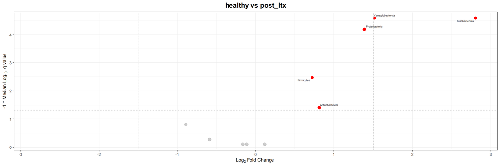

```r
volcano <- ggarrange(volcano_1)
volcano
```

**MaAsLin2**

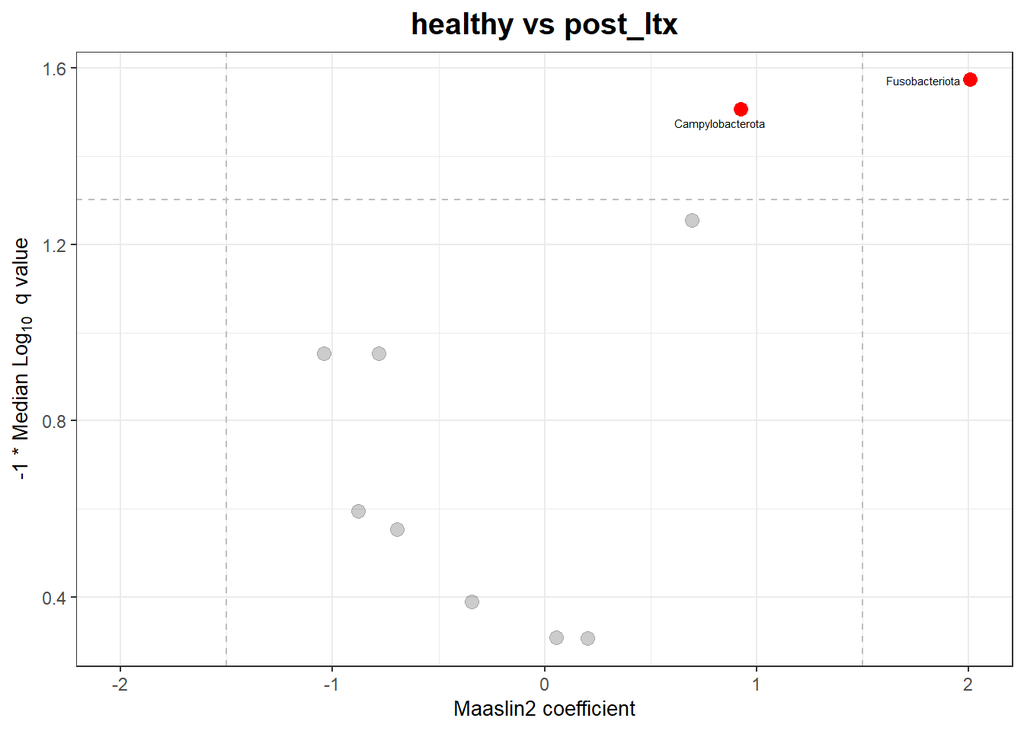

```r
volcano1 <- volcano_plot_maaslin(fit_data,filt_ileum_uni_taxa) +
            ggtitle(comparison_name)

volcano <- ggarrange(volcano1)
volcano
```

**Group - Intersection**

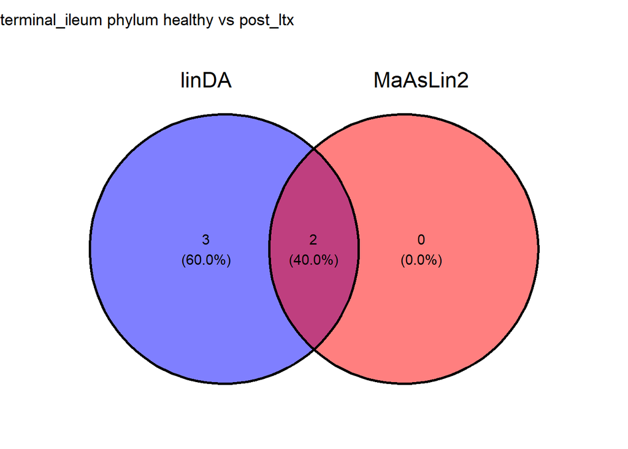

```r
intersection_results <- group_intersection(group, list_intersections, list_venns,
                                           linda.output, fit_data,
                                           raw_linda_results_phylum,
                                           segment = segment,
                                           level=level)

list_intersections <- intersection_results[[1]]
list_venns <- intersection_results[[2]]
venn <- intersection_results[[3]]

# show the results
venn
```

**Basic statistics**

```r
uni_df <-  merge(basic_univariate_statistics(linda_data,group),
                 raw_linda_results_phylum[[segment]][[group1]],
                 by="SeqID",all=TRUE)
```

```
## [1] "healthy"
## [1] "post_ltx"
## [1] "healthy"
## [1] "post_ltx"
```

```r
uni_df[["final_sig"]] <- uni_df$SeqID %in% list_intersections[[paste(segment,level,comparison_name)]][["SeqID"]]
uni_statistics[[segment]][[paste(level,comparison_name)]] <- uni_df

# for comparison
new_name <- paste(level,comparison_name)
addWorksheet(supplements_wb, sheetName = new_name)
writeData(supplements_wb, sheet = new_name, uni_df, rowNames=FALSE)
```

##### Visualization

Heatmap visualizing the linDA’s logFoldChange for taxa with p < 0.1.

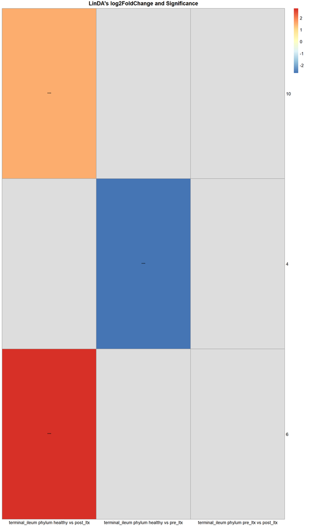

```r
list_heatmap <- list_intersections[grep(paste(segment,level),
                                  names(list_intersections),value=TRUE)]

p_heatmap_linda <- heatmap_linda(list_heatmap,ileum_taxa_tab)
p_heatmap_linda
```

Dot heatmap

```r
dotheatmap_linda <- dot_heatmap_linda(list_heatmap,
                                      uni_df,
                                      ileum_taxa_tab)
```

```
## min_clr -4.023876
## max_clr -0.6380426
## min_log -2.665094
## max_log 2.803749
```

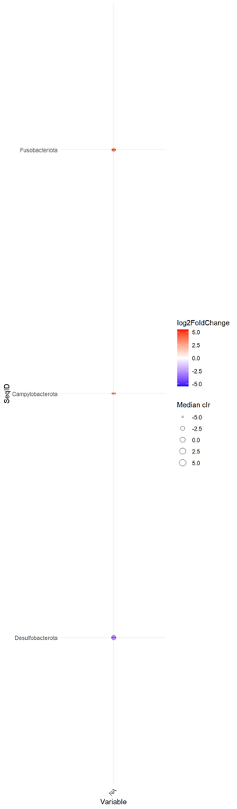

```r
dotheatmap_linda
```

##### PSC effect

**pre_LTx vs Healthy and Post_LTx vs Healthy intersection**

[figure not shown]

```r
A <- list_intersections[[paste(segment,level,"healthy vs pre_ltx")]]$SeqID
B <- list_intersections[[paste(segment,level,"healthy vs post_ltx")]]$SeqID
C <- intersect(A,B)

psc_effect[[paste(segment,level)]] <- list_intersections[[paste(segment,level, "healthy vs pre_ltx")]][list_intersections[[paste(segment,level, "healthy vs pre_ltx")]]$SeqID %in% C,]

# see the results
psc_effect[[paste(segment,level)]]
```

| SeqID | Taxonomy | log2FoldChange | p_value | padj |
| --- | --- | --- | --- | --- |

#### Saving results

```r
# ALL DATA
saveWorkbook(supplements_wb,file.path(path,paste0("supplements_uni_analysis_wb_",segment,".xlsx")),overwrite = TRUE)

# PSC effect
write.xlsx(psc_effect,
          file.path(path,paste0("supplements_psc_effect_",segment,".xlsx")))

# SIGNIFICANT taxa
write.xlsx(list_intersections[grepl(segment,names(list_intersections))] %>%
            `names<-`(gsub(segment, "", names(
              list_intersections[grepl(segment,names(list_intersections))]))),
           file.path(path,paste0("supplements_significant_taxa_",segment,".xlsx")))
```

## Machine learning

```r
path = "../results/Q1_czech/models"
```

### ElasticNet

```r
model="enet"
```

#### ASV level

```r
level="ASV"
```

##### pre_ltx vs healthy

```r
group <- c("pre_ltx","healthy")
comparison_name <- paste0(group[1], " vs ",group[2])
```

```r
model_name <- paste(comparison_name,level,segment)

# prepare the data
filt_ileum_uni_data <- binomial_prep(ileum_asv_tab,
                                     ileum_taxa_tab,
                                     ileum_metadata,
                                     group, usage="ml_clr")
```

```
## Removing 1478 ASV(s)
```

```
## Removing 118 ASV(s)
```

```r
# fit the model
enet_model <- glmnet_binomial(filt_ileum_uni_data,
                              sample_method = "atypboot",
                              outcome="Group",
                              N=10,
                              reuse=TRUE,
                              file=model_name,
                              Q="Q1_czech")

# ROC curve
roc_c <- roc_curve(enet_model, group)
# save the results
models_summ <- list()
models_cm <- list()
betas <- list()
roc_cs <- list()

models_summ[[model_name]] <- enet_model$model_summary
models_cm[[model_name]] <- enet_model$conf_matrices$original
roc_cs[[model_name]] <- enet_model$kfold_rocobjs
betas[[model_name]] <- as.matrix(enet_model$betas)

# see the results
enet_model$model_summary %>% t()
```

```
##                                      [,1]
## alpha                           0.0000000
## lambda                          4.4297736
## auc                             1.0000000
## auc_czech                       1.0000000
## auc_no                                NaN
## auc_optimism_corrected          0.9125173
## auc_optimism_corrected_CIL      0.7460227
## auc_optimism_corrected_CIU      0.9719818
## accuracy                        1.0000000
## accuracy_czech                        NaN
## accuracy_no                           NaN
## accuracy_optimism_corrected     0.8436514
## accuracy_optimism_corrected_CIL 0.6576087
## accuracy_optimism_corrected_CIU 0.9047619
```

```r
enet_model$conf_matrices
```

```
## $original
##     Predicted
## True  0  1
##    0 37  0
##    1  0 24
##
## $czech
##     Predicted
## True  0  1
##    0 37  0
##    1  0 24
##
## $no
## [1] NaN
```

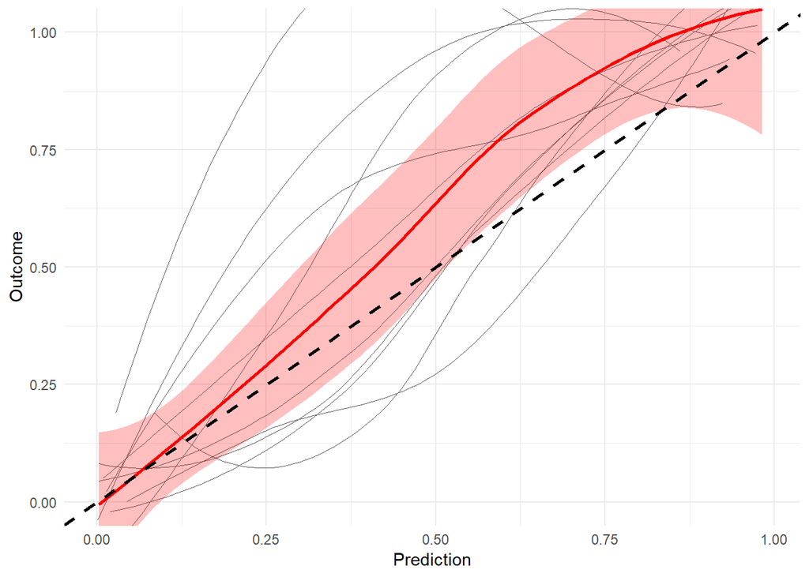

```r
enet_model$plot
```

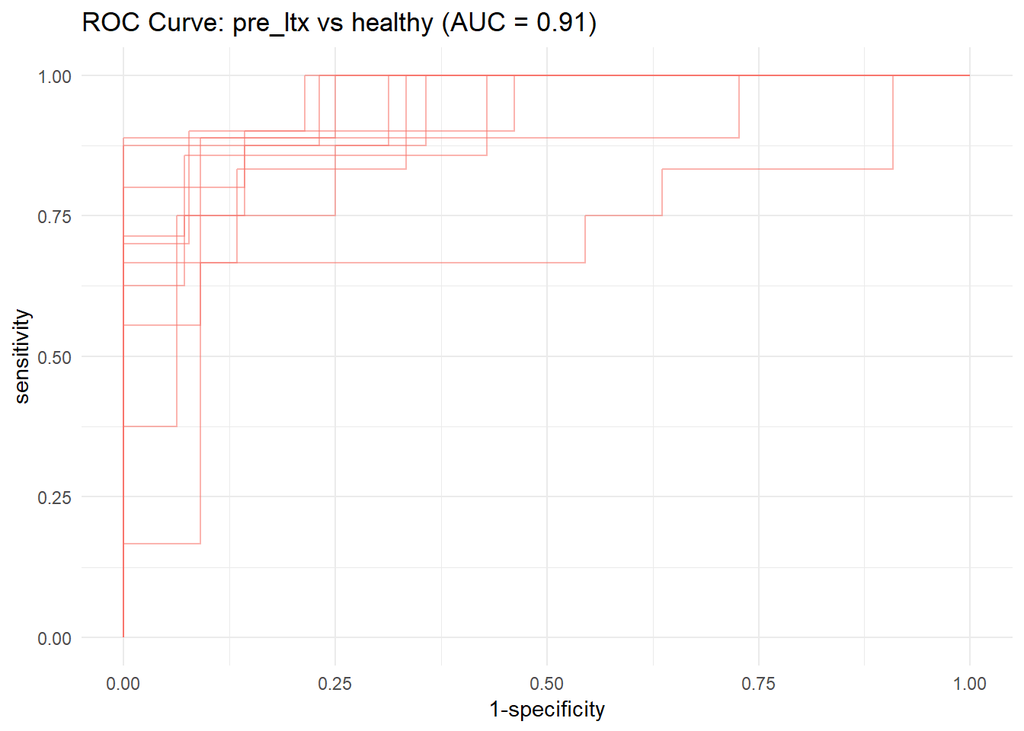

```r
roc_c
```

##### pre_ltx vs post_ltx

```r
group <- c("pre_ltx","post_ltx")
comparison_name <- paste0(group[1], " vs ",group[2])
```

```r
model_name <- paste(comparison_name,level,segment)

# prepare the data
filt_ileum_uni_data <- binomial_prep(ileum_asv_tab,
                                     ileum_taxa_tab,
                                     ileum_metadata,
                                     group,
                                     usage="ml_clr")
```

```
## Removing 555 ASV(s)
```

```
## Removing 36 ASV(s)
```

```r
# fit the model
enet_model <- glmnet_binomial(filt_ileum_uni_data,
                              sample_method = "atypboot",
                              outcome="Group",
                              N=10,
                              reuse=TRUE,
                              file=model_name,
                              Q="Q1_czech")

# ROC
roc_c <- roc_curve(enet_model, group)
# save the results
models_summ[[model_name]] <- enet_model$model_summary
models_cm[[model_name]] <- enet_model$conf_matrices$original
roc_cs[[model_name]] <- enet_model$kfold_rocobjs
betas[[model_name]] <- as.matrix(enet_model$betas)

# see the results
enet_model$model_summary %>% t()
```

```
##                                       [,1]
## alpha                            0.0000000
## lambda                          23.6156255
## auc                              0.9485294
## auc_czech                        0.9485294
## auc_no                                 NaN
## auc_optimism_corrected           0.6948681
## auc_optimism_corrected_CIL       0.5824476
## auc_optimism_corrected_CIU       0.8110143
## accuracy                         0.8095238
## accuracy_czech                         NaN
## accuracy_no                            NaN
## accuracy_optimism_corrected      0.7919350
## accuracy_optimism_corrected_CIL  0.7250614
## accuracy_optimism_corrected_CIU  0.8608075
```

```r
enet_model$conf_matrices
```

```
## $original
##     0
## 0 102 0
## 1  24 0
##
## $czech
##     0
## 0 102 0
## 1  24 0
##
## $no
## [1] NaN
```

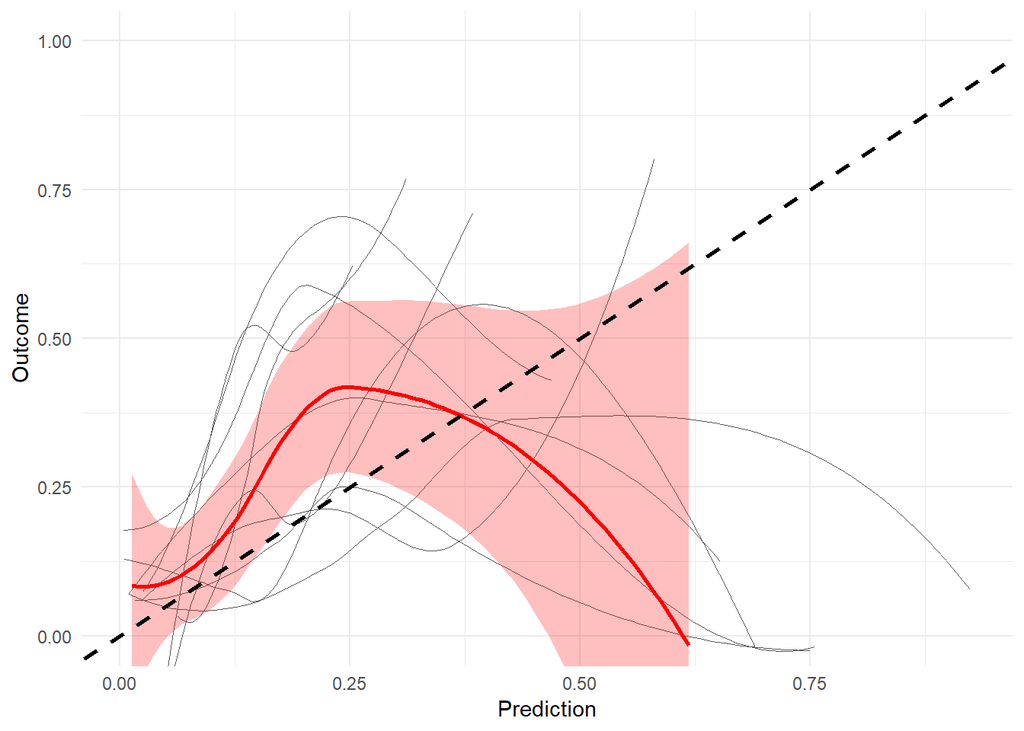

```r
enet_model$plot
```

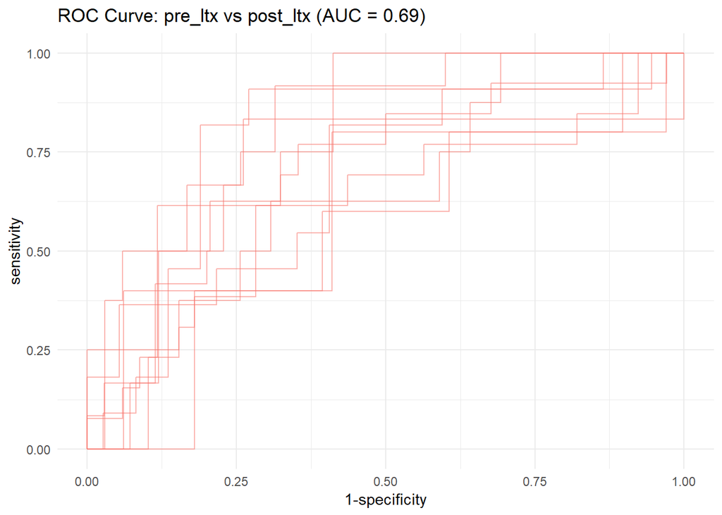

```r
roc_c
```

##### post_ltx vs healthy

```r
group <- c("post_ltx","healthy")
comparison_name <- paste0(group[1], " vs ",group[2])
```

```r
model_name <- paste(comparison_name,level,segment)

# prepare the data
filt_ileum_uni_data <- binomial_prep(ileum_asv_tab,
                                     ileum_taxa_tab,
                                     ileum_metadata,
                                     group,
                                     usage="ml_clr")
```

```
## Removing 260 ASV(s)
```

```
## Removing 48 ASV(s)
```

```r
# fit the model
enet_model <- glmnet_binomial(filt_ileum_uni_data,
                              sample_method = "atypboot",
                              outcome="Group",
                              N=10,
                              reuse=TRUE,
                              file=model_name,
                              Q="Q1_czech")

# ROC
roc_c <- roc_curve(enet_model, group)
# save the results
models_summ[[model_name]] <- enet_model$model_summary
models_cm[[model_name]] <- enet_model$conf_matrices$original
roc_cs[[model_name]] <- enet_model$kfold_rocobjs
betas[[model_name]] <- as.matrix(enet_model$betas)

# see the results
enet_model$model_summary %>% t()
```

```
##                                       [,1]
## alpha                           0.40000000
## lambda                          0.03937419
## auc                             1.00000000
## auc_czech                       1.00000000
## auc_no                                 NaN
## auc_optimism_corrected          0.94206423
## auc_optimism_corrected_CIL      0.90105239
## auc_optimism_corrected_CIU      0.98566042
## accuracy                        1.00000000
## accuracy_czech                         NaN
## accuracy_no                            NaN
## accuracy_optimism_corrected     0.84400802
## accuracy_optimism_corrected_CIL 0.76024411
## accuracy_optimism_corrected_CIU 0.91915820
```

```r
enet_model$conf_matrices
```

```
## $original
##     Predicted
## True   0   1
##    0  37   0
##    1   0 102
##
## $czech
##     Predicted
## True   0   1
##    0  37   0
##    1   0 102
##
## $no
## [1] NaN
```

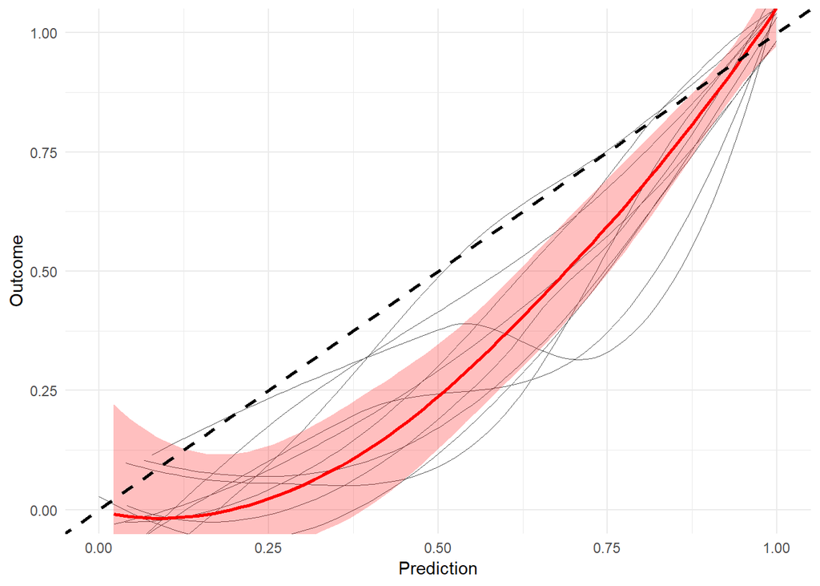

```r
enet_model$plot
```

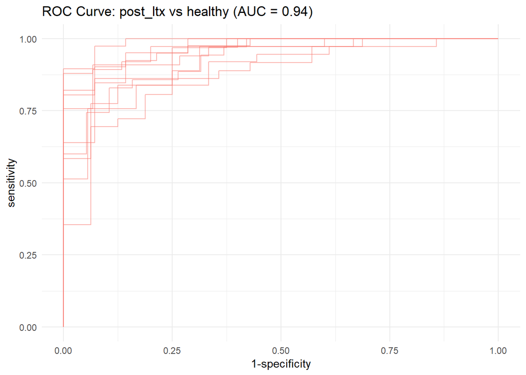

```r
roc_c
```

#### Genus level

```r
level="genus"
```

Aggregate taxa

```r
genus_data <- aggregate_taxa(ileum_asv_tab,
                             ileum_taxa_tab,
                             taxonomic_level = level)

ileum_genus_tab <- genus_data[[1]]
ileum_genus_taxa_tab <- genus_data[[2]]
```

##### pre_ltx vs healthy

```r
group <- c("pre_ltx","healthy")
comparison_name <- paste0(group[1], " vs ",group[2])
```

```r
model_name <- paste(comparison_name,level,segment)

# prepare the data
filt_ileum_uni_data <- binomial_prep(ileum_genus_tab,
                                     ileum_genus_taxa_tab,
                                     ileum_metadata,
                                     group,
                                     usage="ml_clr")
```

```
## Removing 93 ASV(s)
```

```
## Removing 8 ASV(s)
```

```r
# fit the model
enet_model <- glmnet_binomial(filt_ileum_uni_data,
                              sample_method = "atypboot",
                              outcome="Group",
                              N=10,
                              reuse=TRUE,
                              file=model_name,
                              Q="Q1_czech")

# ROC
roc_c <- roc_curve(enet_model, group)
# save the results
models_summ[[model_name]] <- enet_model$model_summary
models_cm[[model_name]] <- enet_model$conf_matrices$original
roc_cs[[model_name]] <- enet_model$kfold_rocobjs
betas[[model_name]] <- as.matrix(enet_model$betas)

# see the results
enet_model$model_summary %>% t()
```

```
##                                      [,1]
## alpha                           0.2000000
## lambda                          0.1579673
## auc                             1.0000000
## auc_czech                       1.0000000
## auc_no                                NaN
## auc_optimism_corrected          0.9130841
## auc_optimism_corrected_CIL      0.8491286
## auc_optimism_corrected_CIU      0.9958333
## accuracy                        1.0000000
## accuracy_czech                        NaN
## accuracy_no                           NaN
## accuracy_optimism_corrected     0.8302828
## accuracy_optimism_corrected_CIL 0.6741848
## accuracy_optimism_corrected_CIU 0.9081169
```

```r
enet_model$conf_matrices
```

```
## $original
##     Predicted
## True  0  1
##    0 37  0
##    1  0 24
##
## $czech
##     Predicted
## True  0  1
##    0 37  0
##    1  0 24
##
## $no
## [1] NaN
```

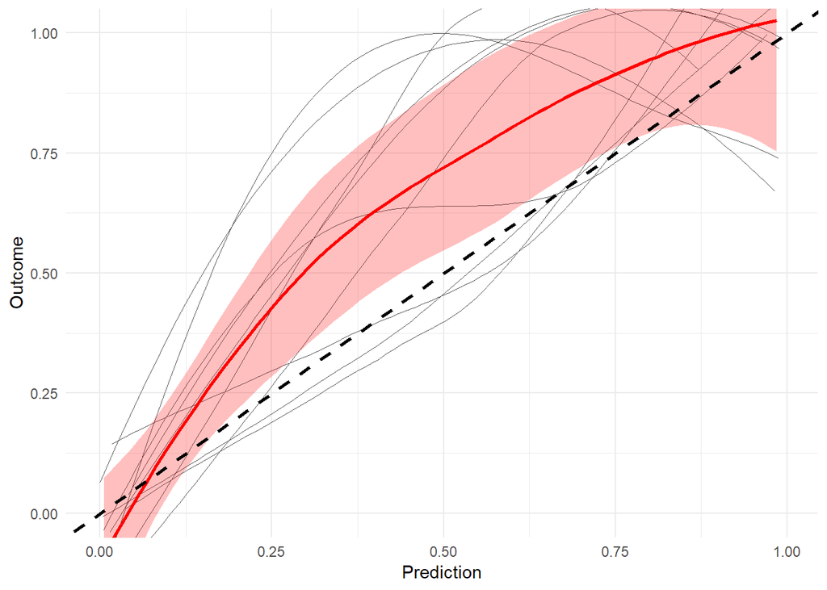

```r
enet_model$plot
```

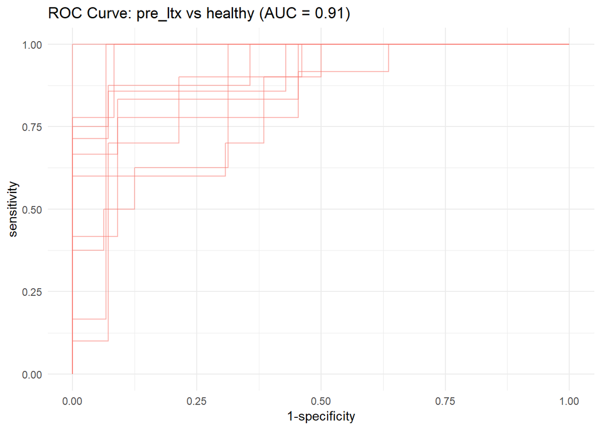

```r
roc_c
```

##### pre_ltx vs post_ltx

```r
group <- c("pre_ltx","post_ltx")
comparison_name <- paste0(group[1], " vs ",group[2])
```

```r
model_name <- paste(comparison_name,level,segment)

# prepare the data
filt_ileum_uni_data <- binomial_prep(ileum_genus_tab,
                                     ileum_genus_taxa_tab,
                                     ileum_metadata,
                                     group,
                                     usage="ml_clr")
```

```
## Removing 41 ASV(s)
```

```
## Removing 3 ASV(s)
```

```r
# fit the model
enet_model <- glmnet_binomial(filt_ileum_uni_data,
                              sample_method = "atypboot",
                              outcome="Group", N=10,
                              reuse=TRUE,
                              file=model_name,
                              Q="Q1_czech")

# ROC
roc_c <- roc_curve(enet_model, group)
# save the results
models_summ[[model_name]] <- enet_model$model_summary
models_cm[[model_name]] <- enet_model$conf_matrices$original
roc_cs[[model_name]] <- enet_model$kfold_rocobjs
betas[[model_name]] <- as.matrix(enet_model$betas)

# see the results
enet_model$model_summary %>% t()
```

```
##                                      [,1]
## alpha                           0.0000000
## lambda                          4.8657540
## auc                             0.9485294
## auc_czech                       0.9485294
## auc_no                                NaN
## auc_optimism_corrected          0.7094762
## auc_optimism_corrected_CIL      0.6273274
## auc_optimism_corrected_CIU      0.8340541
## accuracy                        0.8095238
## accuracy_czech                        NaN
## accuracy_no                           NaN
## accuracy_optimism_corrected     0.7751889
## accuracy_optimism_corrected_CIL 0.6955785
## accuracy_optimism_corrected_CIU 0.8571172
```

```r
enet_model$conf_matrices
```

```
## $original
##     0
## 0 102 0
## 1  24 0
##
## $czech
##     0
## 0 102 0
## 1  24 0
##
## $no
## [1] NaN
```

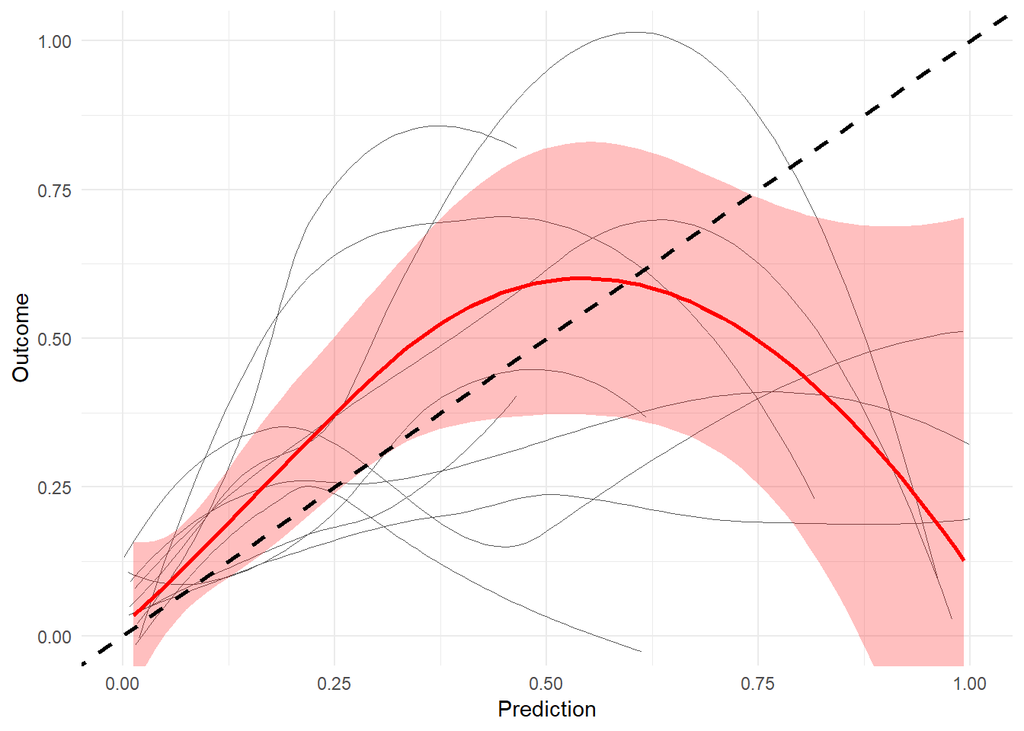

```r
enet_model$plot
```

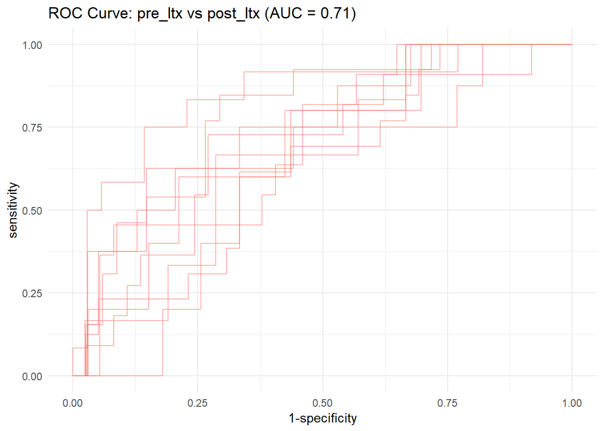

```r
roc_c
```

##### post_ltx vs healthy

```r
group <- c("post_ltx","healthy")
comparison_name <- paste0(group[1], " vs ",group[2])
```

```r
model_name <- paste(comparison_name,level,segment)

# prepare the data
filt_ileum_uni_data <- binomial_prep(ileum_genus_tab,
                                     ileum_genus_taxa_tab,
                                     ileum_metadata,group,
                                     usage="ml_clr")
```

```
## Removing 16 ASV(s)
```

```
## Removing 2 ASV(s)
```

```r
# fit the model
enet_model <- glmnet_binomial(filt_ileum_uni_data,
                              sample_method = "atypboot",
                              outcome="Group",
                              N=10,
                              reuse=TRUE,
                              file=model_name,
                              Q="Q1_czech")

# ROC
roc_c <- roc_curve(enet_model, group)
# save the results
models_summ[[model_name]] <- enet_model$model_summary
models_cm[[model_name]] <- enet_model$conf_matrices$original
roc_cs[[model_name]] <- enet_model$kfold_rocobjs
betas[[model_name]] <- as.matrix(enet_model$betas)

# see the results
enet_model$model_summary %>% t()
```

```
##                                       [,1]
## alpha                           0.40000000
## lambda                          0.02563917
## auc                             1.00000000
## auc_czech                       1.00000000
## auc_no                                 NaN
## auc_optimism_corrected          0.95484421
## auc_optimism_corrected_CIL      0.92410714
## auc_optimism_corrected_CIU      0.99290392
## accuracy                        1.00000000
## accuracy_czech                         NaN
## accuracy_no                            NaN
## accuracy_optimism_corrected     0.88512801
## accuracy_optimism_corrected_CIL 0.83058511
## accuracy_optimism_corrected_CIU 0.93830733
```

```r
enet_model$conf_matrices
```

```
## $original
##     Predicted
## True   0   1
##    0  37   0
##    1   0 102
##
## $czech
##     Predicted
## True   0   1
##    0  37   0
##    1   0 102
##
## $no
## [1] NaN
```

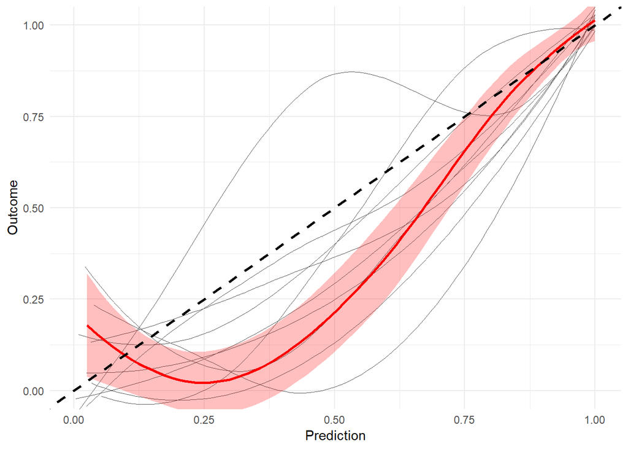

```r
enet_model$plot
```

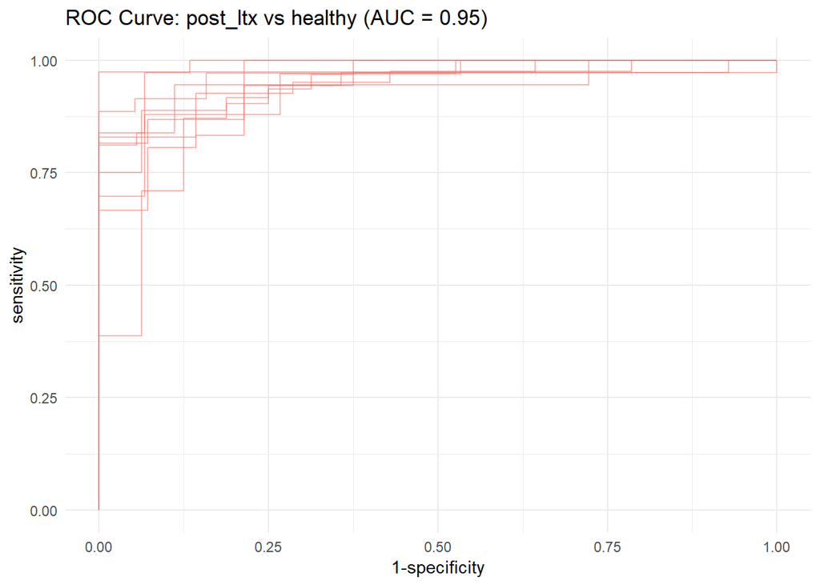

```r
roc_c
```

#### Saving results

```r
models_summ_df_ileum <- do.call(rbind,
  models_summ[grep(segment,names(models_summ),value = TRUE)])

write.csv(models_summ_df_ileum,file.path(path,paste0("elastic_net_",segment,".csv")))
```

### Supplementary models

```r
supplements_models <- list()
```

#### CLR-transformed data

##### kNN

```r
model="knn"
```

###### ASV level

```r
level="ASV"
```

*pre_ltx vs healthy*

```r
group <- c("pre_ltx","healthy")
comparison_name <- paste0(group[1], " vs ",group[2])
```

```r
model_name <- paste(comparison_name,level,segment)

# prepare the data
filt_ileum_uni_data <- binomial_prep(ileum_asv_tab,
                                     ileum_taxa_tab,
                                     ileum_metadata,
                                     group, usage="ml_clr")
```

```
## Removing 1478 ASV(s)
```

```
## Removing 118 ASV(s)
```

```r
# fit the model
knn_model <- knn_binomial(filt_ileum_uni_data,
                              sample_method = "atypboot",
                              outcome="Group",
                              N=10,
                              reuse=TRUE,
                              file=model_name,
                              Q="Q1_czech")

# ROC curve
roc_c <- roc_curve(knn_model, group)
# save the results
supplements_models[["models_summ"]][["knn_model"]][[model_name]] <- knn_model$model_summary
supplements_models[["roc_cs"]][["knn_model"]][[model_name]] <- knn_model$kfold_rocobjs

# see the results
knn_model$model_summary %>% t()
```

```
##                                       [,1]
## k                               19.0000000
## auc                              0.9481982
## auc_optimism_corrected           0.9111788
## auc_optimism_corrected_CIL       0.8459517
## auc_optimism_corrected_CIU       0.9668485
## accuracy                         0.8852459
## accuracy_optimism_corrected      0.8197064
## accuracy_optimism_corrected_CIL  0.7415761
## accuracy_optimism_corrected_CIU  0.9047619
```

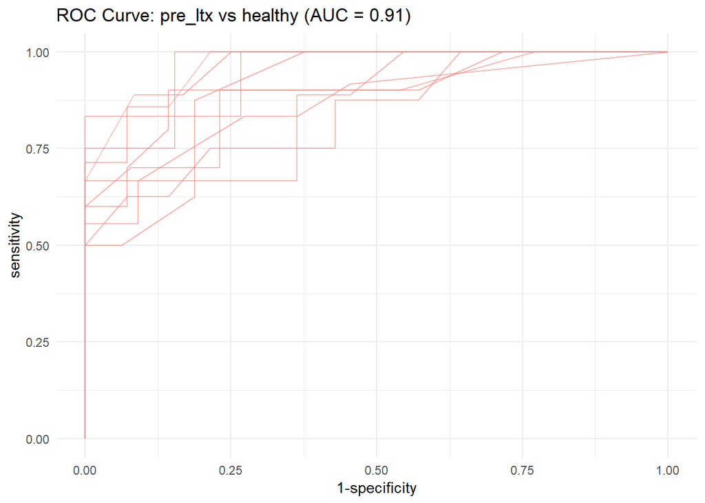

```r
roc_c
```

**pre_ltx vs post_ltx**

```r
group <- c("pre_ltx","post_ltx")
comparison_name <- paste0(group[1], " vs ",group[2])
```

```r
model_name <- paste(comparison_name,level,segment)


# prepare the data
filt_ileum_uni_data <- binomial_prep(ileum_asv_tab,
                                     ileum_taxa_tab,
                                     ileum_metadata,
                                     group, usage="ml_clr")
```

```
## Removing 555 ASV(s)
```

```
## Removing 36 ASV(s)
```

```r
# fit the model
knn_model <- knn_binomial(filt_ileum_uni_data,
                              sample_method = "atypboot",
                              outcome="Group",
                              N=10,
                              reuse=TRUE,
                              file=model_name,
                              Q="Q1_czech")

# ROC curve
roc_c <- roc_curve(knn_model, group)
# save the results
supplements_models[["models_summ"]][["knn_model"]][[model_name]] <- knn_model$model_summary
supplements_models[["roc_cs"]][["knn_model"]][[model_name]] <- knn_model$kfold_rocobjs


# see the results
knn_model$model_summary %>% t()
```

```
##                                       [,1]
## k                               11.0000000
## auc                              0.8386438
## auc_optimism_corrected           0.6766450
## auc_optimism_corrected_CIL       0.5849351
## auc_optimism_corrected_CIU       0.7871080
## accuracy                         0.8333333
## accuracy_optimism_corrected      0.7752687
## accuracy_optimism_corrected_CIL  0.7326574
## accuracy_optimism_corrected_CIU  0.8345170
```

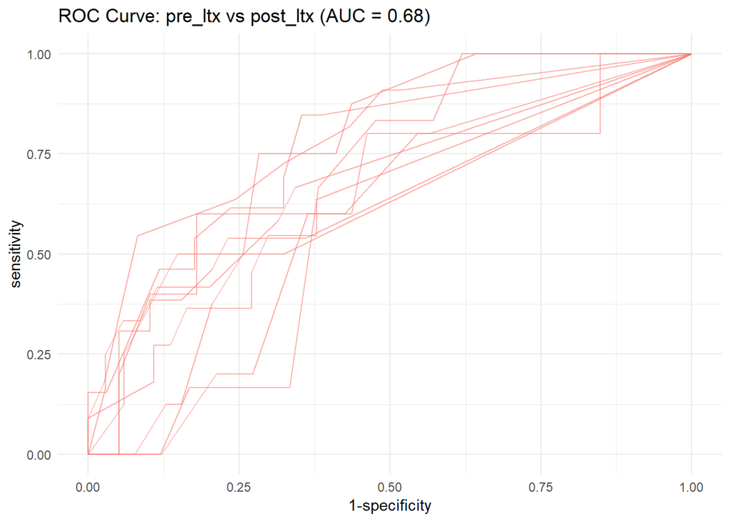

```r
roc_c
```

**post_ltx vs healthy**

```r
group <- c("post_ltx","healthy")
comparison_name <- paste0(group[1], " vs ",group[2])
```

```r
model_name <- paste(comparison_name,level,segment)

# prepare the data
filt_ileum_uni_data <- binomial_prep(ileum_asv_tab,
                                     ileum_taxa_tab,
                                     ileum_metadata,
                                     group, usage="ml_clr")
```

```
## Removing 260 ASV(s)
```

```
## Removing 48 ASV(s)
```

```r
# fit the model
knn_model <- knn_binomial(filt_ileum_uni_data,
                              sample_method = "atypboot",
                              outcome="Group",
                              N=10,
                              reuse=TRUE,
                              file=model_name,
                              Q="Q1_czech")

# ROC curve
roc_c <- roc_curve(knn_model, group)
# save the results
# save the results
supplements_models[["models_summ"]][["knn_model"]][[model_name]] <- knn_model$model_summary
supplements_models[["roc_cs"]][["knn_model"]][[model_name]] <- knn_model$kfold_rocobjs

# see the results
knn_model$model_summary %>% t()
```

```
##                                       [,1]
## k                               12.0000000
## auc                              0.9048755
## auc_optimism_corrected           0.8180820
## auc_optimism_corrected_CIL       0.7052114
## auc_optimism_corrected_CIU       0.9524700
## accuracy                         0.8848921
## accuracy_optimism_corrected      0.7978793
## accuracy_optimism_corrected_CIL  0.7233586
## accuracy_optimism_corrected_CIU  0.8995192
```

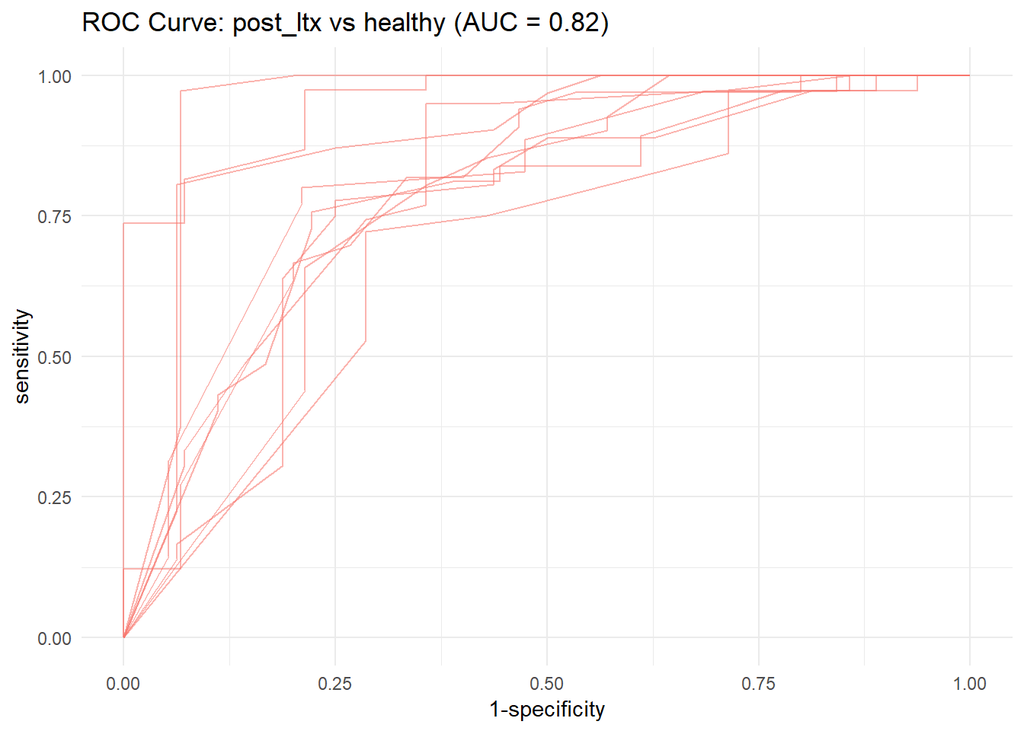

```r
roc_c
```

###### Genus level

```r
level="genus"
```

Aggregate taxa

```r
genus_data <- aggregate_taxa(ileum_asv_tab,
                             ileum_taxa_tab,
                             taxonomic_level = level)

ileum_genus_tab <- genus_data[[1]]
ileum_genus_taxa_tab <- genus_data[[2]]
```

**pre_ltx vs healthy**

```r
group <- c("pre_ltx","healthy")
comparison_name <- paste0(group[1], " vs ",group[2])
```

```r
model_name <- paste(comparison_name,level,segment)

# prepare the data
filt_ileum_uni_data <- binomial_prep(ileum_genus_tab,
                                     ileum_genus_taxa_tab,
                                     ileum_metadata,
                                     group,
                                     usage="ml_clr")
```

```
## Removing 93 ASV(s)
```

```
## Removing 8 ASV(s)
```

```r
# fit the model
knn_model <- knn_binomial(filt_ileum_uni_data,
                              sample_method = "atypboot",
                              outcome="Group",
                              N=10,
                              reuse=TRUE,
                              file=model_name,
                              Q="Q1_czech")

# ROC curve
roc_c <- roc_curve(knn_model, group)
# save the results
supplements_models[["models_summ"]][["knn_model"]][[model_name]] <- knn_model$model_summary
supplements_models[["roc_cs"]][["knn_model"]][[model_name]] <- knn_model$kfold_rocobjs


# see the results
knn_model$model_summary %>% t()
```

```
##                                       [,1]
## k                               10.0000000
## auc                              0.9549550
## auc_optimism_corrected           0.8580076
## auc_optimism_corrected_CIL       0.7908357
## auc_optimism_corrected_CIU       0.9711779
## accuracy                         0.7540984
## accuracy_optimism_corrected      0.7098720
## accuracy_optimism_corrected_CIL  0.6110248
## accuracy_optimism_corrected_CIU  0.8055195
```

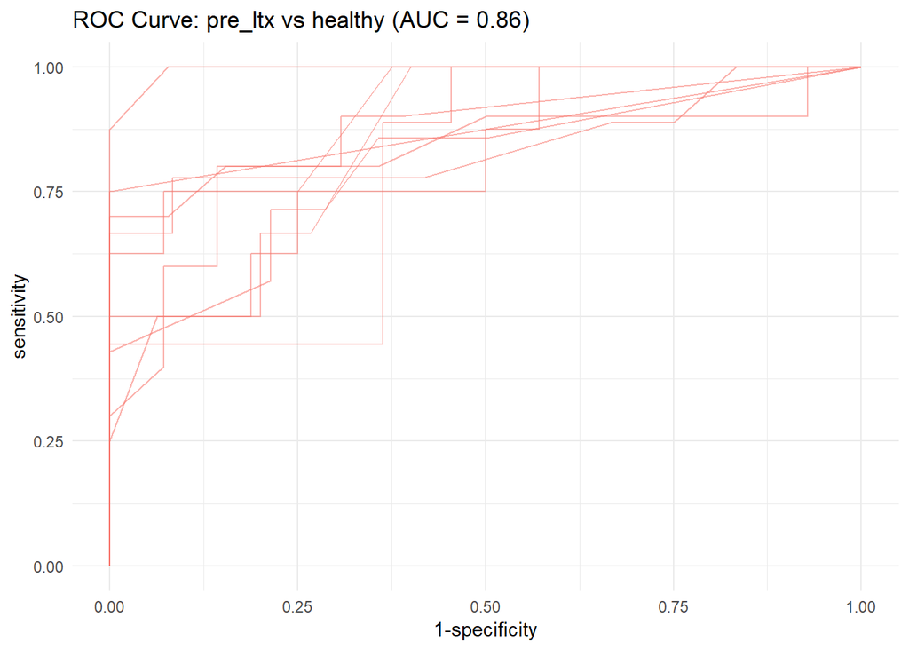

```r
roc_c
```

**pre_ltx vs post_ltx**

```r
group <- c("pre_ltx","post_ltx")
comparison_name <- paste0(group[1], " vs ",group[2])
```

```r
model_name <- paste(comparison_name,level,segment)

# prepare the data
filt_ileum_uni_data <- binomial_prep(ileum_genus_tab,
                                     ileum_genus_taxa_tab,
                                     ileum_metadata,
                                     group,
                                     usage="ml_clr")
```

```
## Removing 41 ASV(s)
```

```
## Removing 3 ASV(s)
```

```r
# fit the model
knn_model <- knn_binomial(filt_ileum_uni_data,
                              sample_method = "atypboot",
                              outcome="Group",
                              N=10,
                              reuse=TRUE,
                              file=model_name,
                              Q="Q1_czech")

# ROC curve
roc_c <- roc_curve(knn_model, group)
# save the results
supplements_models[["models_summ"]][["knn_model"]][[model_name]] <- knn_model$model_summary
supplements_models[["roc_cs"]][["knn_model"]][[model_name]] <- knn_model$kfold_rocobjs


# see the results
knn_model$model_summary %>% t()
```

```
##                                       [,1]
## k                               14.0000000
## auc                              0.8415033
## auc_optimism_corrected           0.6934488
## auc_optimism_corrected_CIL       0.5589627
## auc_optimism_corrected_CIU       0.8054960
## accuracy                         0.8174603
## accuracy_optimism_corrected      0.7932043
## accuracy_optimism_corrected_CIL  0.7117243
## accuracy_optimism_corrected_CIU  0.8937027
```

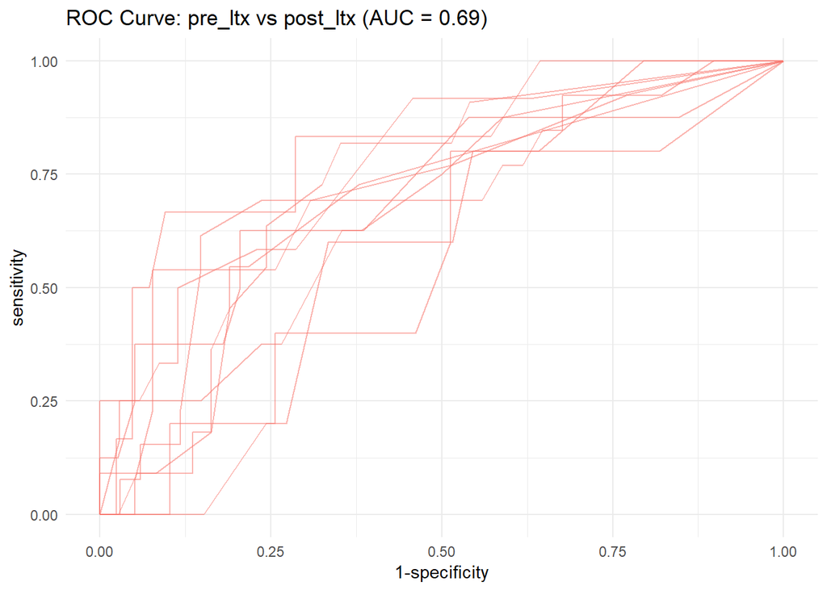

```r
roc_c
```

**post_ltx vs healthy**

```r
group <- c("post_ltx","healthy")
comparison_name <- paste0(group[1], " vs ",group[2])
```

```r
model_name <- paste(comparison_name,level,segment)

# prepare the data
filt_ileum_uni_data <- binomial_prep(ileum_genus_tab,
                                     ileum_genus_taxa_tab,
                                     ileum_metadata,
                                     group,
                                     usage="ml_clr")
```

```
## Removing 16 ASV(s)
```

```
## Removing 2 ASV(s)
```

```r
# fit the model
knn_model <- knn_binomial(filt_ileum_uni_data,
                              sample_method = "atypboot",
                              outcome="Group",
                              N=10,
                              reuse=TRUE,
                              file=model_name,
                              Q="Q1_czech")

# ROC curve
roc_c <- roc_curve(knn_model, group)
# save the results
supplements_models[["models_summ"]][["knn_model"]][[model_name]] <- knn_model$model_summary
supplements_models[["roc_cs"]][["knn_model"]][[model_name]] <- knn_model$kfold_rocobjs


# see the results
knn_model$model_summary %>% t()
```

```
##                                       [,1]
## k                               19.0000000
## auc                              0.9670111
## auc_optimism_corrected           0.8924815
## auc_optimism_corrected_CIL       0.8406156
## auc_optimism_corrected_CIU       0.9616798
## accuracy                         0.8848921
## accuracy_optimism_corrected      0.8002149
## accuracy_optimism_corrected_CIL  0.7323864
## accuracy_optimism_corrected_CIU  0.8894930
```

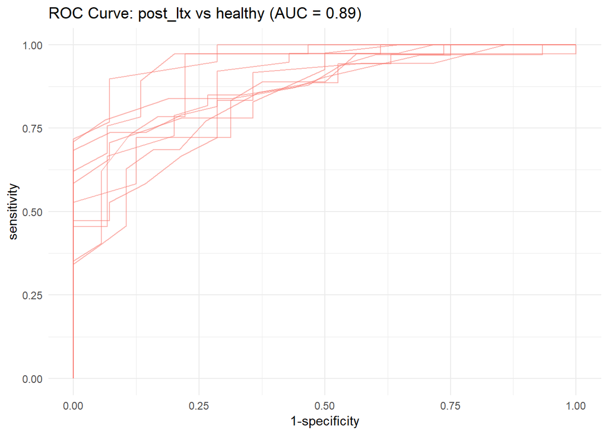

```r
roc_c
```

##### Random Forest

```r
model="rf"
```

###### ASV level

```r
level="ASV"
```

*pre_ltx vs healthy*

```r
group <- c("pre_ltx","healthy")
comparison_name <- paste0(group[1], " vs ",group[2])
```

```r
model_name <- paste(comparison_name,level,segment)

# prepare the data
filt_ileum_uni_data <- binomial_prep(ileum_asv_tab,
                                     ileum_taxa_tab,
                                     ileum_metadata,
                                     group, usage="ml_clr")
```

```
## Removing 1478 ASV(s)
```

```
## Removing 118 ASV(s)
```

```r
# fit the model
rf_model <- rf_binomial(filt_ileum_uni_data,
                              sample_method = "atypboot",
                              outcome="Group",
                              N=10,
                              reuse=TRUE,
                              file=model_name,
                              Q="Q1_czech")

# ROC curve
roc_c <- roc_curve(rf_model, group)
# save the results
supplements_models[["models_summ"]][["rf_model"]][[model_name]] <- rf_model$model_summary
supplements_models[["roc_cs"]][["rf_model"]][[model_name]] <- rf_model$kfold_rocobjs

# see the results
rf_model$model_summary %>% t()
```

```
##                                 [,1]
## mtry                            "13"
## splitrule                       "gini"
## min.node.size                   "2"
## auc                             "1"
## auc_optimism_corrected          "0.8287759"
## auc_optimism_corrected_CIL      "0.5771336"
## auc_optimism_corrected_CIU      "0.9839286"
## accuracy                        "1"
## accuracy_optimism_corrected     "0.7672228"
## accuracy_optimism_corrected_CIL "0.6215217"
## accuracy_optimism_corrected_CIU "0.8724432"
```

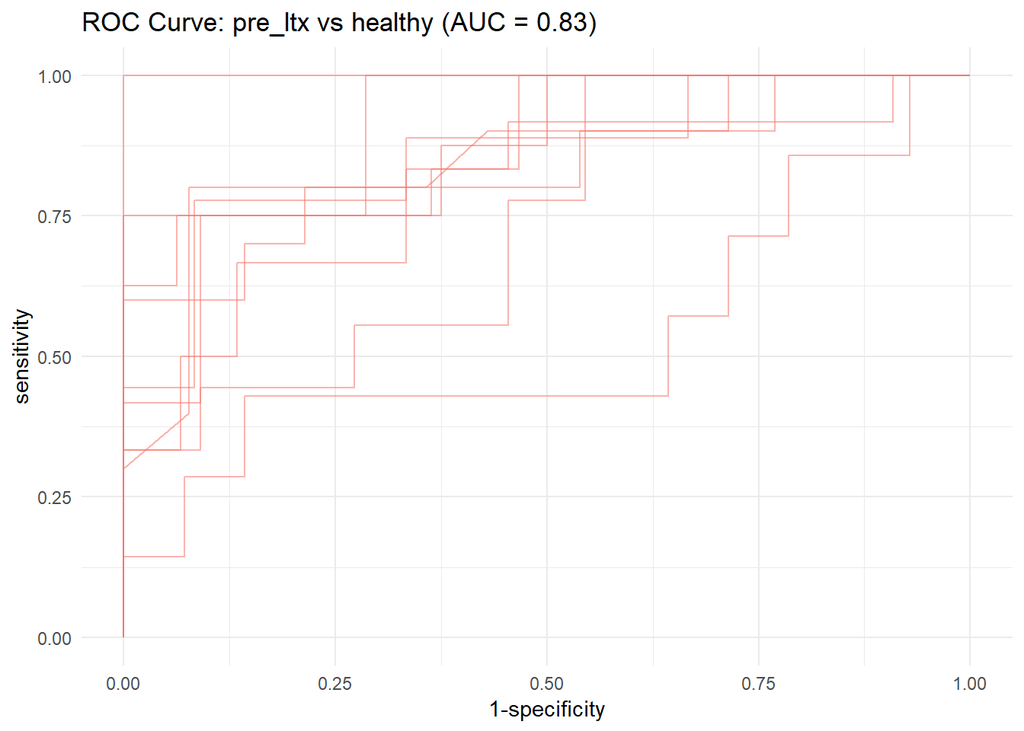

```r
roc_c
```

**pre_ltx vs post_ltx**

```r
group <- c("pre_ltx","post_ltx")
comparison_name <- paste0(group[1], " vs ",group[2])
```

```r
model_name <- paste(comparison_name,level,segment)

# prepare the data
filt_ileum_uni_data <- binomial_prep(ileum_asv_tab,
                                     ileum_taxa_tab,
                                     ileum_metadata,
                                     group, usage="ml_clr")
```

```
## Removing 555 ASV(s)
```

```
## Removing 36 ASV(s)
```

```r
# fit the model
rf_model <- rf_binomial(filt_ileum_uni_data,
                              sample_method = "atypboot",
                              outcome="Group",
                              N=10,
                              reuse=TRUE,
                              file=model_name,
                              Q="Q1_czech")

# ROC curve
roc_c <- roc_curve(rf_model, group)
# save the results
supplements_models[["models_summ"]][["rf_model"]][[model_name]] <- rf_model$model_summary
supplements_models[["roc_cs"]][["rf_model"]][[model_name]] <- rf_model$kfold_rocobjs

# see the results
rf_model$model_summary %>% t()
```

```
##                                 [,1]
## mtry                            "43"
## splitrule                       "gini"
## min.node.size                   "5"
## auc                             "1"
## auc_optimism_corrected          "0.6561724"
## auc_optimism_corrected_CIL      "0.5778259"
## auc_optimism_corrected_CIU      "0.7348714"
## accuracy                        "1"
## accuracy_optimism_corrected     "0.7743705"
## accuracy_optimism_corrected_CIL "0.696875"
## accuracy_optimism_corrected_CIU "0.8384067"
```

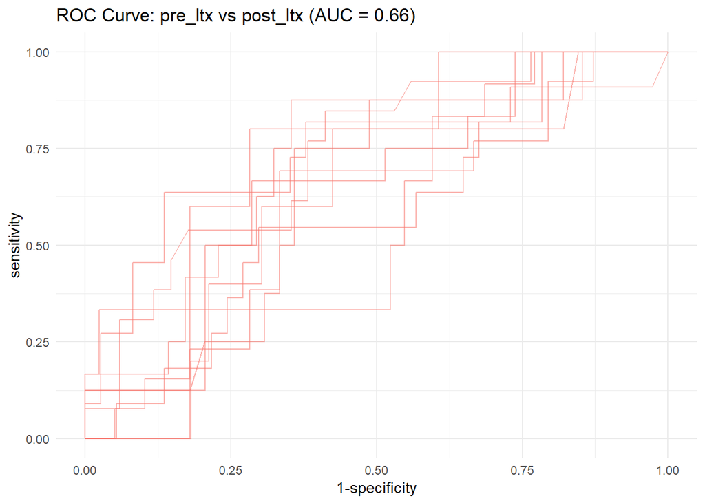

```r
roc_c
```

**post_ltx vs healthy**

```r
group <- c("post_ltx","healthy")
comparison_name <- paste0(group[1], " vs ",group[2])
```

```r
model_name <- paste(comparison_name,level,segment)

# prepare the data
filt_ileum_uni_data <- binomial_prep(ileum_asv_tab,
                                     ileum_taxa_tab,
                                     ileum_metadata,
                                     group, usage="ml_clr")
```

```
## Removing 260 ASV(s)
```

```
## Removing 48 ASV(s)
```

```r
# fit the model
rf_model <- rf_binomial(filt_ileum_uni_data,
                              sample_method = "atypboot",
                              outcome="Group",
                              N=10,
                              reuse=TRUE,
                              file=model_name,
                              Q="Q1_czech")

# ROC curve
roc_c <- roc_curve(rf_model, group)
# save the results
supplements_models[["models_summ"]][["rf_model"]][[model_name]] <- rf_model$model_summary
supplements_models[["roc_cs"]][["rf_model"]][[model_name]] <- rf_model$kfold_rocobjs

# see the results
rf_model$model_summary %>% t()
```

```
##                                 [,1]
## mtry                            "149"
## splitrule                       "gini"
## min.node.size                   "5"
## auc                             "1"
## auc_optimism_corrected          "0.8650417"
## auc_optimism_corrected_CIL      "0.7467677"
## auc_optimism_corrected_CIU      "0.948142"
## accuracy                        "1"
## accuracy_optimism_corrected     "0.846914"
## accuracy_optimism_corrected_CIL "0.8"
## accuracy_optimism_corrected_CIU "0.916964"
```

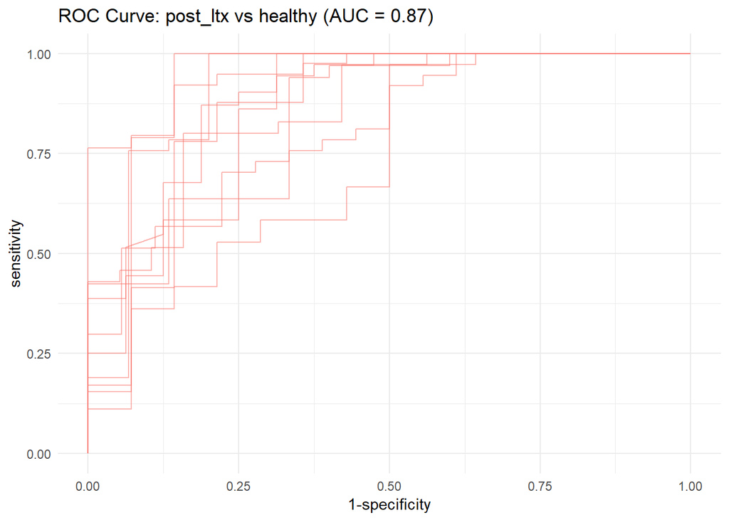

```r
roc_c
```

###### Genus level

```r
level="genus"
```

Aggregate taxa

```r
genus_data <- aggregate_taxa(ileum_asv_tab,
                             ileum_taxa_tab,
                             taxonomic_level = level)

ileum_genus_tab <- genus_data[[1]]
ileum_genus_taxa_tab <- genus_data[[2]]
```

**pre_ltx vs healthy**

```r
group <- c("pre_ltx","healthy")
comparison_name <- paste0(group[1], " vs ",group[2])
```

```r
model_name <- paste(comparison_name,level,segment)

# prepare the data
filt_ileum_uni_data <- binomial_prep(ileum_genus_tab,
                                     ileum_genus_taxa_tab,
                                     ileum_metadata,
                                     group,
                                     usage="ml_clr")
```

```
## Removing 93 ASV(s)
```

```
## Removing 8 ASV(s)
```

```r
# fit the model
rf_model <- rf_binomial(filt_ileum_uni_data,
                              sample_method = "atypboot",
                              outcome="Group",
                              N=10,
                              reuse=TRUE,
                              file=model_name,
                              Q="Q1_czech")

# ROC curve
roc_c <- roc_curve(rf_model, group)
# save the results
supplements_models[["models_summ"]][["rf_model"]][[model_name]] <- rf_model$model_summary
supplements_models[["roc_cs"]][["rf_model"]][[model_name]] <- rf_model$kfold_rocobjs

# see the results
rf_model$model_summary %>% t()
```

```
##                                 [,1]
## mtry                            "121"
## splitrule                       "gini"
## min.node.size                   "2"
## auc                             "1"
## auc_optimism_corrected          "0.8817009"
## auc_optimism_corrected_CIL      "0.7688763"
## auc_optimism_corrected_CIU      "0.9631799"
## accuracy                        "1"
## accuracy_optimism_corrected     "0.760551"
## accuracy_optimism_corrected_CIL "0.6504891"
## accuracy_optimism_corrected_CIU "0.8621753"
```

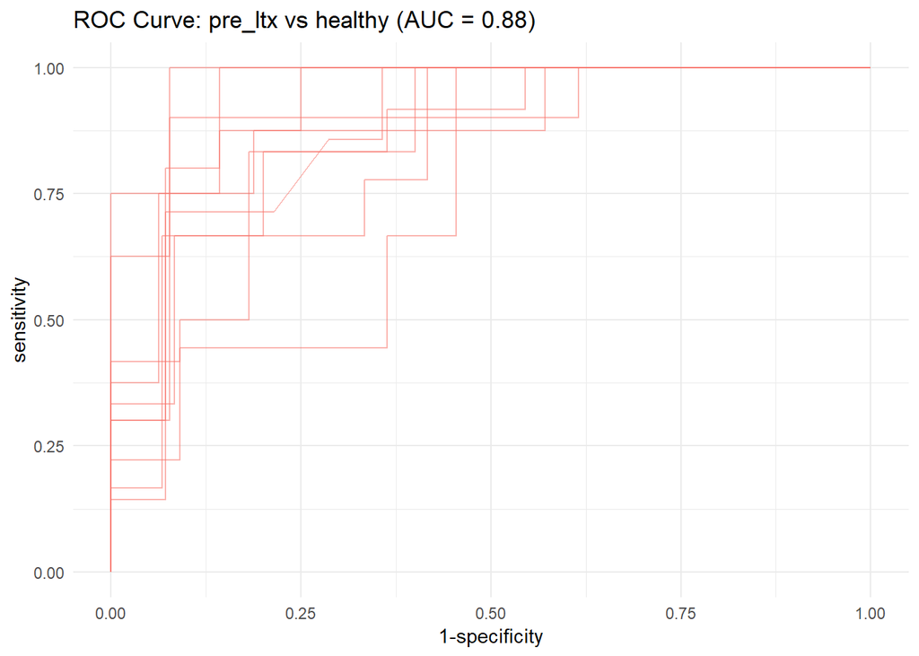

```r
roc_c
```

**pre_ltx vs post_ltx**

```r
group <- c("pre_ltx","post_ltx")
comparison_name <- paste0(group[1], " vs ",group[2])
```

```r
model_name <- paste(comparison_name,level,segment)

# prepare the data
filt_ileum_uni_data <- binomial_prep(ileum_genus_tab,
                                     ileum_genus_taxa_tab,
                                     ileum_metadata,
                                     group,
                                     usage="ml_clr")
```

```
## Removing 41 ASV(s)
```

```
## Removing 3 ASV(s)
```

```r
# fit the model
rf_model <- rf_binomial(filt_ileum_uni_data,
                              sample_method = "atypboot",
                              outcome="Group",
                              N=10,
                              reuse=TRUE,
                              file=model_name,
                              Q="Q1_czech")

# ROC curve
roc_c <- roc_curve(rf_model, group)
# save the results
supplements_models[["models_summ"]][["rf_model"]][[model_name]] <- rf_model$model_summary
supplements_models[["roc_cs"]][["rf_model"]][[model_name]] <- rf_model$kfold_rocobjs

# see the results
rf_model$model_summary %>% t()
```

```
##                                 [,1]
## mtry                            "7"
## splitrule                       "gini"
## min.node.size                   "2"
## auc                             "1"
## auc_optimism_corrected          "0.7082342"
## auc_optimism_corrected_CIL      "0.5029177"
## auc_optimism_corrected_CIU      "0.8629418"
## accuracy                        "1"
## accuracy_optimism_corrected     "0.7716928"
## accuracy_optimism_corrected_CIL "0.7083333"
## accuracy_optimism_corrected_CIU "0.8392045"
```

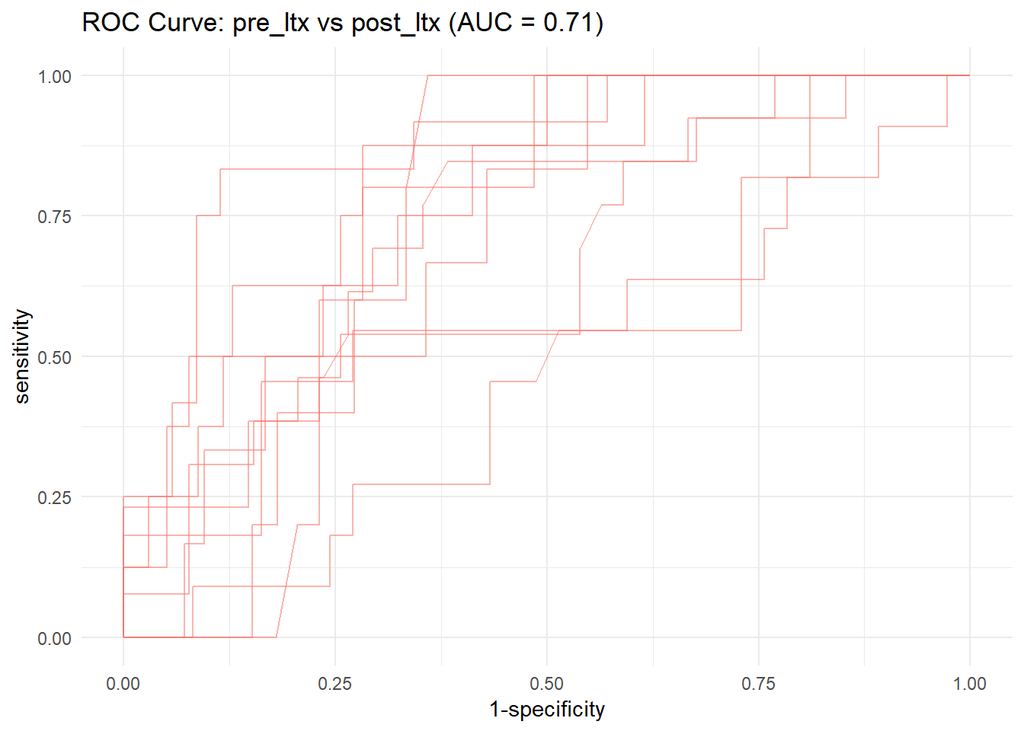

```r
roc_c
```

**post_ltx vs healthy**

```r
group <- c("post_ltx","healthy")
comparison_name <- paste0(group[1], " vs ",group[2])
```

```r
model_name <- paste(comparison_name,level,segment)

# prepare the data
filt_ileum_uni_data <- binomial_prep(ileum_genus_tab,
                                     ileum_genus_taxa_tab,
                                     ileum_metadata,
                                     group,
                                     usage="ml_clr")
```

```
## Removing 16 ASV(s)
```

```
## Removing 2 ASV(s)
```

```r
# fit the model
rf_model <- rf_binomial(filt_ileum_uni_data,
                              sample_method = "atypboot",
                              outcome="Group",
                              N=10,
                              reuse=TRUE,
                              file=model_name,
                              Q="Q1_czech")

# ROC curve
roc_c <- roc_curve(rf_model, group)
# save the results
supplements_models[["models_summ"]][["rf_model"]][[model_name]] <- rf_model$model_summary
supplements_models[["roc_cs"]][["rf_model"]][[model_name]] <- rf_model$kfold_rocobjs

# see the results
rf_model$model_summary %>% t()
```

```
##                                 [,1]
## mtry                            "33"
## splitrule                       "gini"
## min.node.size                   "5"
## auc                             "1"
## auc_optimism_corrected          "0.8529435"
## auc_optimism_corrected_CIL      "0.7198997"
## auc_optimism_corrected_CIU      "0.9273955"
## accuracy                        "1"
## accuracy_optimism_corrected     "0.8159999"
## accuracy_optimism_corrected_CIL "0.7118762"
## accuracy_optimism_corrected_CIU "0.9344975"
```

```r
roc_c
```

[output not shown]

##### Gradient boosting

```r
model="gb"
```

###### ASV level

```r
level="ASV"
```

*pre_ltx vs healthy*

```r
group <- c("pre_ltx","healthy")
comparison_name <- paste0(group[1], " vs ",group[2])
```

```r
model_name <- paste(comparison_name,level,segment)

# prepare the data
filt_ileum_uni_data <- binomial_prep(ileum_asv_tab,
                                     ileum_taxa_tab,
                                     ileum_metadata,
                                     group, usage="ml_clr")
```

```
## Removing 1478 ASV(s)
```

```
## Removing 118 ASV(s)
```

```r
# fit the model
gbm_model <- gbm_binomial(filt_ileum_uni_data,
                              sample_method = "atypboot",
                              outcome="Group",
                              N=10,
                              reuse=TRUE,
                              file=model_name,
                              Q="Q1_czech")

# ROC curve
roc_c <- roc_curve(gbm_model, group)
# save the results
supplements_models[["models_summ"]][["gbm_model"]][[model_name]] <- gbm_model$model_summary
supplements_models[["roc_cs"]][["gbm_model"]][[model_name]] <- gbm_model$kfold_rocobjs

# see the results
gbm_model$model_summary %>% t()
```

```
##                                 [,1]
## mtry                            "33"
## splitrule                       "gini"
## min.node.size                   "5"
## auc                             "1"
## auc_optimism_corrected          "0.8529435"
## auc_optimism_corrected_CIL      "0.7198997"
## auc_optimism_corrected_CIU      "0.9273955"
## accuracy                        "1"
## accuracy_optimism_corrected     "0.8159999"
## accuracy_optimism_corrected_CIL "0.7118762"
## accuracy_optimism_corrected_CIU "0.9344975"
```

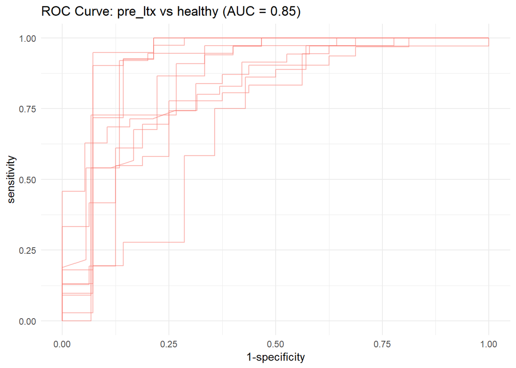

```r
roc_c
```

**pre_ltx vs post_ltx**

```r
group <- c("pre_ltx","post_ltx")
comparison_name <- paste0(group[1], " vs ",group[2])
```

```r
model_name <- paste(comparison_name,level,segment)

# prepare the data
filt_ileum_uni_data <- binomial_prep(ileum_asv_tab,
                                     ileum_taxa_tab,
                                     ileum_metadata,
                                     group, usage="ml_clr")
```

```
## Removing 555 ASV(s)
```

```
## Removing 36 ASV(s)
```

```r
# fit the model
gbm_model <- gbm_binomial(filt_ileum_uni_data,
                              sample_method = "atypboot",
                              outcome="Group",
                              N=10,
                              reuse=TRUE,
                              file=model_name,
                              Q="Q1_czech")

# ROC curve
roc_c <- roc_curve(gbm_model, group)
# save the results
supplements_models[["models_summ"]][["gbm_model"]][[model_name]] <- gbm_model$model_summary
supplements_models[["roc_cs"]][["gbm_model"]][[model_name]] <- gbm_model$kfold_rocobjs


# see the results
gbm_model$model_summary %>% t()
```

```
##                                 [,1]
## mtry                            "33"
## splitrule                       "gini"
## min.node.size                   "5"
## auc                             "1"
## auc_optimism_corrected          "0.8529435"
## auc_optimism_corrected_CIL      "0.7198997"
## auc_optimism_corrected_CIU      "0.9273955"
## accuracy                        "1"
## accuracy_optimism_corrected     "0.8159999"
## accuracy_optimism_corrected_CIL "0.7118762"
## accuracy_optimism_corrected_CIU "0.9344975"
```

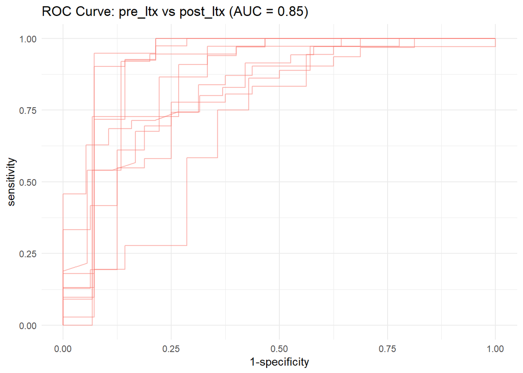

```r
roc_c
```

**post_ltx vs healthy**

```r
group <- c("post_ltx","healthy")
comparison_name <- paste0(group[1], " vs ",group[2])
```

```r
model_name <- paste(comparison_name,level,segment)

# prepare the data
filt_ileum_uni_data <- binomial_prep(ileum_asv_tab,
                                     ileum_taxa_tab,
                                     ileum_metadata,
                                     group, usage="ml_clr")
```

```
## Removing 260 ASV(s)
```

```
## Removing 48 ASV(s)
```

```r
# fit the model
gbm_model <- gbm_binomial(filt_ileum_uni_data,
                              sample_method = "atypboot",
                              outcome="Group",
                              N=10,
                              reuse=TRUE,
                              file=model_name,
                              Q="Q1_czech")

# ROC curve
roc_c <- roc_curve(gbm_model, group)
# save the results
supplements_models[["models_summ"]][["gbm_model"]][[model_name]] <- gbm_model$model_summary
supplements_models[["roc_cs"]][["gbm_model"]][[model_name]] <- gbm_model$kfold_rocobjs


# see the results
gbm_model$model_summary %>% t()
```

```
##                                 [,1]
## mtry                            "33"
## splitrule                       "gini"
## min.node.size                   "5"
## auc                             "1"
## auc_optimism_corrected          "0.8529435"
## auc_optimism_corrected_CIL      "0.7198997"
## auc_optimism_corrected_CIU      "0.9273955"
## accuracy                        "1"
## accuracy_optimism_corrected     "0.8159999"
## accuracy_optimism_corrected_CIL "0.7118762"
## accuracy_optimism_corrected_CIU "0.9344975"
```

```r
roc_c
```

###### Genus level

```r
level="genus"
```

Aggregate taxa

```r
genus_data <- aggregate_taxa(ileum_asv_tab,
                             ileum_taxa_tab,
                             taxonomic_level = level)

ileum_genus_tab <- genus_data[[1]]
ileum_genus_taxa_tab <- genus_data[[2]]
```

**pre_ltx vs healthy**

```r
group <- c("pre_ltx","healthy")
comparison_name <- paste0(group[1], " vs ",group[2])
```

```r
model_name <- paste(comparison_name,level,segment)

# prepare the data
filt_ileum_uni_data <- binomial_prep(ileum_genus_tab,
                                     ileum_genus_taxa_tab,
                                     ileum_metadata,
                                     group,
                                     usage="ml_clr")
```

```
## Removing 93 ASV(s)
```

```
## Removing 8 ASV(s)
```

```r
# fit the model
gbm_model <- gbm_binomial(filt_ileum_uni_data,
                              sample_method = "atypboot",
                              outcome="Group",
                              N=10,
                              reuse=TRUE,
                              file=model_name,
                              Q="Q1_czech")

# ROC curve
roc_c <- roc_curve(gbm_model, group)
# save the results
supplements_models[["models_summ"]][["gbm_model"]][[model_name]] <- gbm_model$model_summary
supplements_models[["roc_cs"]][["gbm_model"]][[model_name]] <- gbm_model$kfold_rocobjs

# see the results
gbm_model$model_summary %>% t()
```

```
##                                 [,1]
## mtry                            "33"
## splitrule                       "gini"
## min.node.size                   "5"
## auc                             "1"
## auc_optimism_corrected          "0.8529435"
## auc_optimism_corrected_CIL      "0.7198997"
## auc_optimism_corrected_CIU      "0.9273955"
## accuracy                        "1"
## accuracy_optimism_corrected     "0.8159999"
## accuracy_optimism_corrected_CIL "0.7118762"
## accuracy_optimism_corrected_CIU "0.9344975"
```

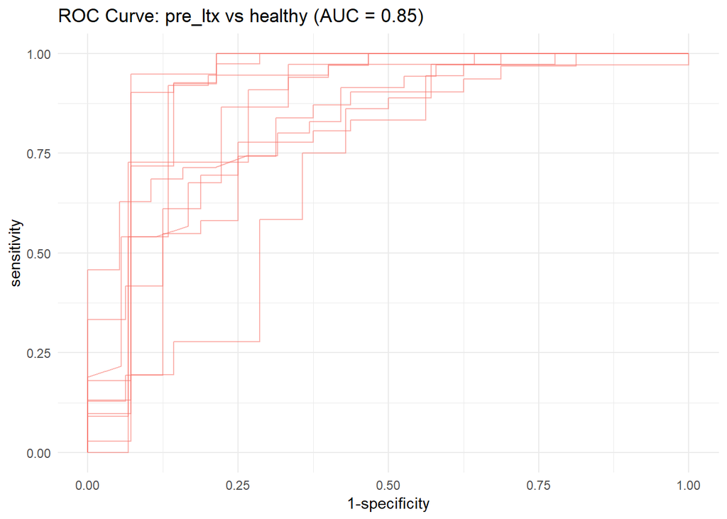

```r
roc_c
```

**pre_ltx vs post_ltx**

```r
group <- c("pre_ltx","post_ltx")
comparison_name <- paste0(group[1], " vs ",group[2])
```

```r
model_name <- paste(comparison_name,level,segment)

# prepare the data
filt_ileum_uni_data <- binomial_prep(ileum_genus_tab,
                                     ileum_genus_taxa_tab,
                                     ileum_metadata,
                                     group,
                                     usage="ml_clr")
```

```
## Removing 41 ASV(s)
```

```
## Removing 3 ASV(s)
```

```r
# fit the model
gbm_model <- gbm_binomial(filt_ileum_uni_data,
                              sample_method = "atypboot",
                              outcome="Group",
                              N=10,
                              reuse=TRUE,
                              file=model_name,
                              Q="Q1_czech")

# ROC curve
roc_c <- roc_curve(gbm_model, group)
# save the results
supplements_models[["models_summ"]][["gbm_model"]][[model_name]] <- gbm_model$model_summary
supplements_models[["roc_cs"]][["gbm_model"]][[model_name]] <- gbm_model$kfold_rocobjs

# see the results
gbm_model$model_summary %>% t()
```

```
##                                 [,1]
## mtry                            "33"
## splitrule                       "gini"
## min.node.size                   "5"
## auc                             "1"
## auc_optimism_corrected          "0.8529435"
## auc_optimism_corrected_CIL      "0.7198997"
## auc_optimism_corrected_CIU      "0.9273955"
## accuracy                        "1"
## accuracy_optimism_corrected     "0.8159999"
## accuracy_optimism_corrected_CIL "0.7118762"
## accuracy_optimism_corrected_CIU "0.9344975"
```

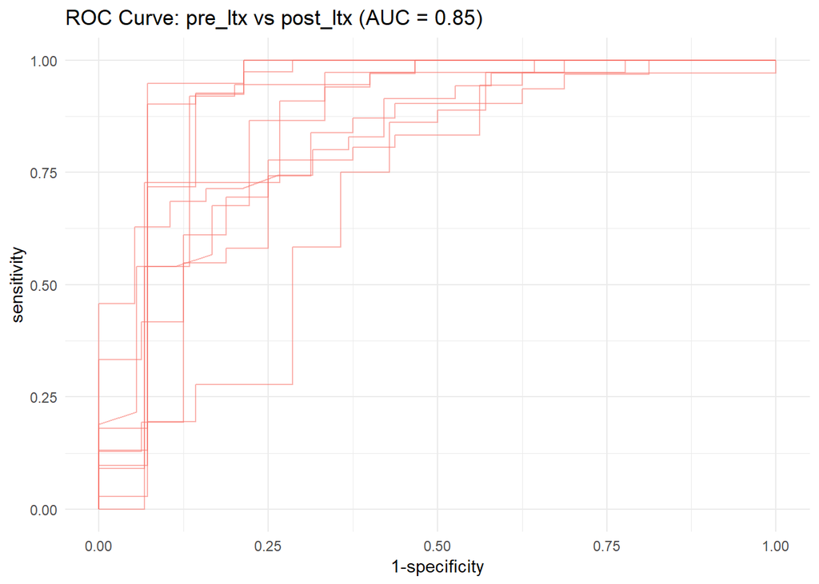

```r
roc_c
```

**post_ltx vs healthy**

```r
group <- c("post_ltx","healthy")
comparison_name <- paste0(group[1], " vs ",group[2])
```

```r
model_name <- paste(comparison_name,level,segment)

# prepare the data
filt_ileum_uni_data <- binomial_prep(ileum_genus_tab,
                                     ileum_genus_taxa_tab,
                                     ileum_metadata,
                                     group,
                                     usage="ml_clr")
```

```
## Removing 16 ASV(s)
```

```
## Removing 2 ASV(s)
```

```r
# fit the model
gbm_model <- gbm_binomial(filt_ileum_uni_data,
                              sample_method = "atypboot",
                              outcome="Group",
                              N=10,
                              reuse=TRUE,
                              file=model_name,
                              Q="Q1_czech")

# ROC curve
roc_c <- roc_curve(gbm_model, group)
# save the results
supplements_models[["models_summ"]][["gbm_model"]][[model_name]] <- gbm_model$model_summary
supplements_models[["roc_cs"]][["gbm_model"]][[model_name]] <- gbm_model$kfold_rocobjs

# see the results
gbm_model$model_summary %>% t()
```

```
##                                 [,1]
## mtry                            "33"
## splitrule                       "gini"
## min.node.size                   "5"
## auc                             "1"
## auc_optimism_corrected          "0.8529435"
## auc_optimism_corrected_CIL      "0.7198997"
## auc_optimism_corrected_CIU      "0.9273955"
## accuracy                        "1"
## accuracy_optimism_corrected     "0.8159999"
## accuracy_optimism_corrected_CIL "0.7118762"
## accuracy_optimism_corrected_CIU "0.9344975"
```

```r
roc_c
```

#### Relative abundances

##### Elastic net

###### ASV level

```r
level="ASV"
```

*pre_ltx vs healthy*

```r
group <- c("pre_ltx","healthy")
comparison_name <- paste0(group[1], " vs ",group[2])
```

```r
model_name <- paste(comparison_name,level,segment)

# prepare the data
filt_ileum_uni_data <- binomial_prep(ileum_asv_tab,
                                     ileum_taxa_tab,
                                     ileum_metadata,
                                     group, usage="ml_ra")
```

```
## Removing 1478 ASV(s)
```

```
## Removing 118 ASV(s)
```

```r
# fit the model
enet_model <- glmnet_binomial(filt_ileum_uni_data,
                              sample_method = "atypboot",
                              outcome="Group",
                              N=10,
                              reuse=TRUE,
                              file=model_name,
                              Q="Q1_czech")

# ROC curve
roc_c <- roc_curve(enet_model, group)
# save the results
supplements_models[["models_summ"]][["enet_model_ra"]][[model_name]] <- enet_model$model_summary

supplements_models[["roc_cs"]][["enet_model_ra"]][[model_name]] <- enet_model$kfold_rocobjs

# see the results
enet_model$model_summary %>% t()
```

```
##                                      [,1]
## alpha                           0.2000000
## lambda                          0.3778764
## auc                             1.0000000
## auc_czech                       1.0000000
## auc_no                                NaN
## auc_optimism_corrected          0.8454954
## auc_optimism_corrected_CIL      0.7061699
## auc_optimism_corrected_CIU      0.9437710
## accuracy                        1.0000000
## accuracy_czech                        NaN
## accuracy_no                           NaN
## accuracy_optimism_corrected     0.7949445
## accuracy_optimism_corrected_CIL 0.6998447
## accuracy_optimism_corrected_CIU 0.8709821
```

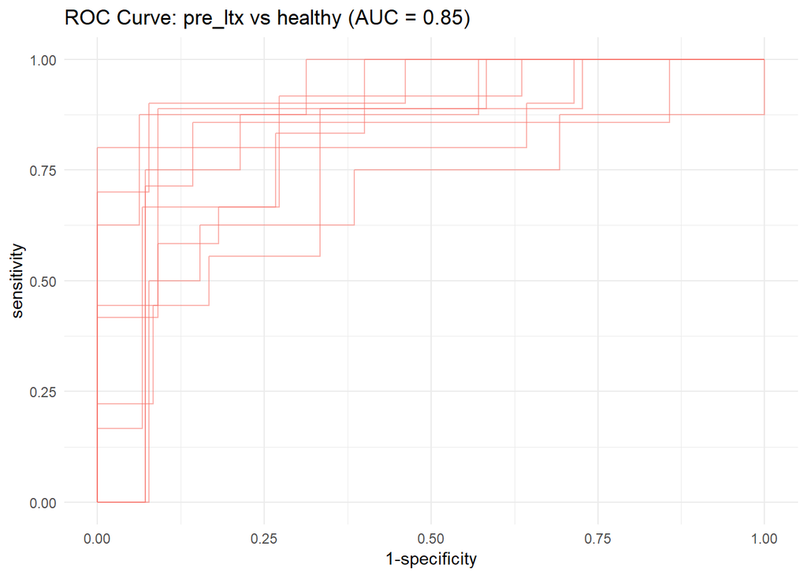

```r
roc_c
```

**pre_ltx vs post_ltx**

```r
group <- c("pre_ltx","post_ltx")
comparison_name <- paste0(group[1], " vs ",group[2])
```

```r
model_name <- paste(comparison_name,level,segment)

# prepare the data
filt_ileum_uni_data <- binomial_prep(ileum_asv_tab,
                                     ileum_taxa_tab,
                                     ileum_metadata,
                                     group, usage="ml_ra")
```

```
## Removing 555 ASV(s)
```

```
## Removing 36 ASV(s)
```

```r
# fit the model
enet_model <- glmnet_binomial(filt_ileum_uni_data,
                              sample_method = "atypboot",
                              outcome="Group",
                              N=10,
                              reuse=TRUE,
                              file=model_name,
                              Q="Q1_czech")

# ROC curve
roc_c <- roc_curve(enet_model, group)
# save the results
supplements_models[["models_summ"]][["enet_model_ra"]][[model_name]] <- enet_model$model_summary

supplements_models[["roc_cs"]][["enet_model_ra"]][[model_name]] <- enet_model$kfold_rocobjs

# see the results
enet_model$model_summary %>% t()
```

```
##                                        [,1]
## alpha                             0.0000000
## lambda                          102.5526002
## auc                               0.9971405
## auc_czech                         0.9971405
## auc_no                                  NaN
## auc_optimism_corrected            0.5652716
## auc_optimism_corrected_CIL        0.3719551
## auc_optimism_corrected_CIU        0.8215233
## accuracy                          0.8095238
## accuracy_czech                          NaN
## accuracy_no                             NaN
## accuracy_optimism_corrected       0.7872688
## accuracy_optimism_corrected_CIL   0.7117021
## accuracy_optimism_corrected_CIU   0.8568182
```

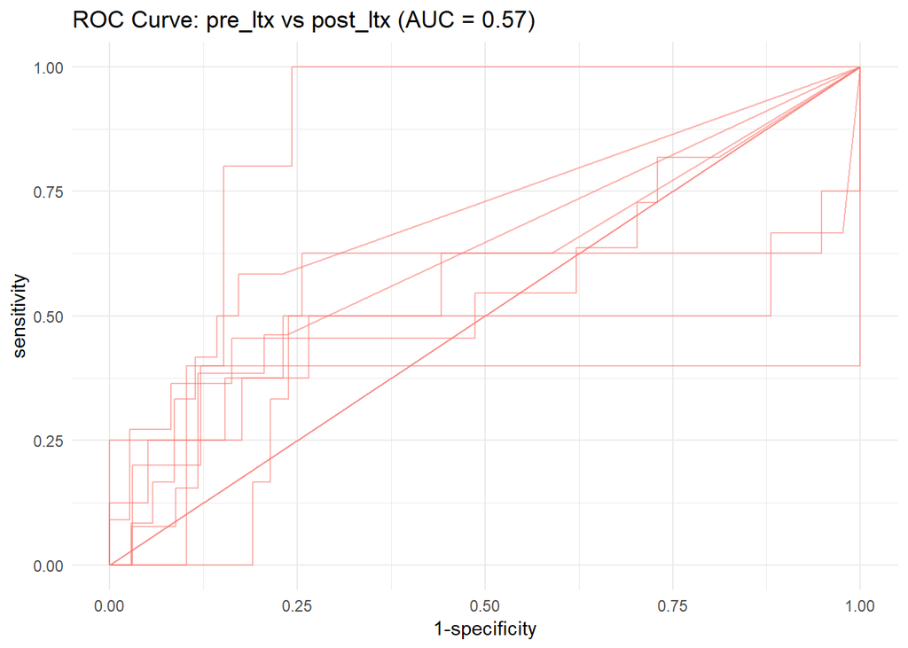

```r
roc_c
```

**post_ltx vs healthy**

```r
group <- c("post_ltx","healthy")
comparison_name <- paste0(group[1], " vs ",group[2])
```

```r
model_name <- paste(comparison_name,level,segment)


# prepare the data
filt_ileum_uni_data <- binomial_prep(ileum_asv_tab,
                                     ileum_taxa_tab,
                                     ileum_metadata,
                                     group, usage="ml_ra")
```

```
## Removing 260 ASV(s)
```

```
## Removing 48 ASV(s)
```

```r
# fit the model
enet_model <- glmnet_binomial(filt_ileum_uni_data,
                              sample_method = "atypboot",
                              outcome="Group",
                              N=10,
                              reuse=TRUE,
                              file=model_name,
                              Q="Q1_czech")

# ROC curve
roc_c <- roc_curve(enet_model, group)
# save the results
supplements_models[["models_summ"]][["enet_model_ra"]][[model_name]] <- enet_model$model_summary

supplements_models[["roc_cs"]][["enet_model_ra"]][[model_name]] <- enet_model$kfold_rocobjs

# see the results
enet_model$model_summary %>% t()
```

```
##                                      [,1]
## alpha                           0.0000000
## lambda                          3.5362260
## auc                             1.0000000
## auc_czech                       1.0000000
## auc_no                                NaN
## auc_optimism_corrected          0.7951580
## auc_optimism_corrected_CIL      0.7080357
## auc_optimism_corrected_CIU      0.8688125
## accuracy                        0.8776978
## accuracy_czech                        NaN
## accuracy_no                           NaN
## accuracy_optimism_corrected     0.7518252
## accuracy_optimism_corrected_CIL 0.6646915
## accuracy_optimism_corrected_CIU 0.8251270
```

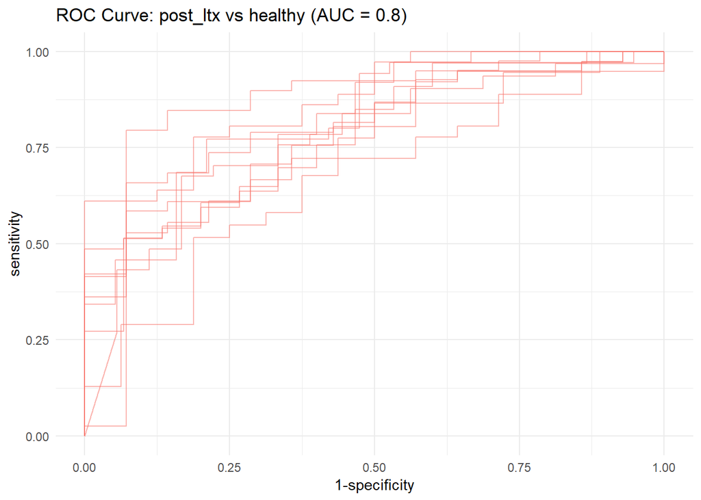

```r
roc_c
```

###### Genus level

```r
level="genus"
```

Aggregate taxa

```r
genus_data <- aggregate_taxa(ileum_asv_tab,
                             ileum_taxa_tab,
                             taxonomic_level = level)

ileum_genus_tab <- genus_data[[1]]
ileum_genus_taxa_tab <- genus_data[[2]]
```

**pre_ltx vs healthy**

```r
group <- c("pre_ltx","healthy")
comparison_name <- paste0(group[1], " vs ",group[2])
```

```r
model_name <- paste(comparison_name,level,segment)

# prepare the data
filt_ileum_uni_data <- binomial_prep(ileum_genus_tab,
                                     ileum_genus_taxa_tab,
                                     ileum_metadata,
                                     group,
                                     usage="ml_ra")
```

```
## Removing 93 ASV(s)
```

```
## Removing 8 ASV(s)
```

```r
# fit the model
enet_model <- glmnet_binomial(filt_ileum_uni_data,
                              sample_method = "atypboot",
                              outcome="Group",
                              N=10,
                              reuse=TRUE,
                              file=model_name,
                              Q="Q1_czech")

# ROC curve
roc_c <- roc_curve(enet_model, group)
# save the results
supplements_models[["models_summ"]][["enet_model_ra"]][[model_name]] <- enet_model$model_summary

supplements_models[["roc_cs"]][["enet_model_ra"]][[model_name]] <- enet_model$kfold_rocobjs

# see the results
enet_model$model_summary %>% t()
```

```
##                                      [,1]
## alpha                           0.0000000
## lambda                          8.2397352
## auc                             1.0000000
## auc_czech                       1.0000000
## auc_no                                NaN
## auc_optimism_corrected          0.8509168
## auc_optimism_corrected_CIL      0.7440741
## auc_optimism_corrected_CIU      0.9829545
## accuracy                        0.8032787
## accuracy_czech                        NaN
## accuracy_no                           NaN
## accuracy_optimism_corrected     0.7805345
## accuracy_optimism_corrected_CIL 0.6731884
## accuracy_optimism_corrected_CIU 0.9339583
```

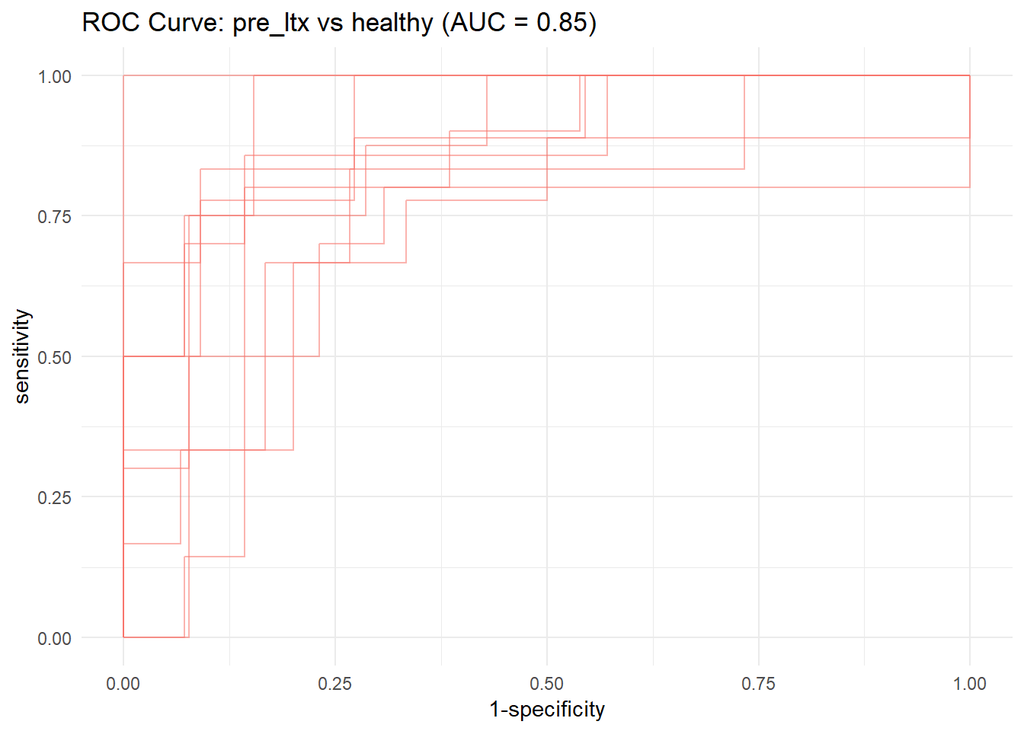

```r
roc_c
```

**pre_ltx vs post_ltx**

```r
group <- c("pre_ltx","post_ltx")
comparison_name <- paste0(group[1], " vs ",group[2])
```

```r
model_name <- paste(comparison_name,level,segment)


# prepare the data
filt_ileum_uni_data <- binomial_prep(ileum_genus_tab,
                                     ileum_genus_taxa_tab,
                                     ileum_metadata,
                                     group,
                                     usage="ml_ra")
```

```
## Removing 41 ASV(s)
```

```
## Removing 3 ASV(s)
```

```r
# fit the model
enet_model <- glmnet_binomial(filt_ileum_uni_data,
                              sample_method = "atypboot",
                              outcome="Group",
                              N=10,
                              reuse=TRUE,
                              file=model_name,
                              Q="Q1_czech")

# ROC curve
roc_c <- roc_curve(enet_model, group)
# save the results
supplements_models[["models_summ"]][["enet_model_ra"]][[model_name]] <- enet_model$model_summary

supplements_models[["roc_cs"]][["enet_model_ra"]][[model_name]] <- enet_model$kfold_rocobjs

# see the results
enet_model$model_summary %>% t()
```

```
##                                        [,1]
## alpha                             0.0000000
## lambda                          130.6178958
## auc                               0.9791667
## auc_czech                         0.9791667
## auc_no                                  NaN
## auc_optimism_corrected            0.6084429
## auc_optimism_corrected_CIL        0.4915927
## auc_optimism_corrected_CIU        0.7402786
## accuracy                          0.8095238
## accuracy_czech                          NaN
## accuracy_no                             NaN
## accuracy_optimism_corrected       0.7930146
## accuracy_optimism_corrected_CIL   0.7350962
## accuracy_optimism_corrected_CIU   0.8823266
```

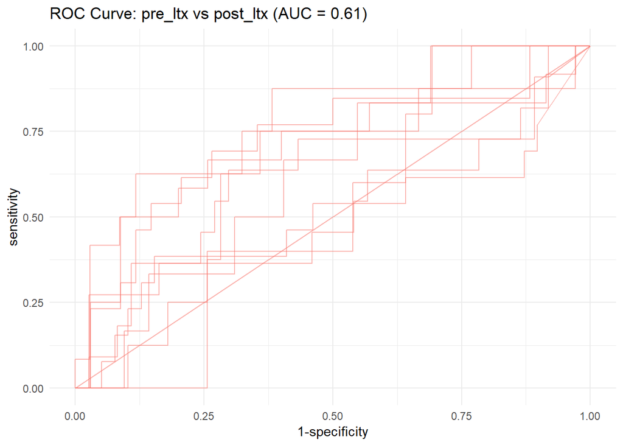

```r
roc_c
```

**post_ltx vs healthy**

```r
group <- c("post_ltx","healthy")
comparison_name <- paste0(group[1], " vs ",group[2])
```

```r
model_name <- paste(comparison_name,level,segment)

# prepare the data
filt_ileum_uni_data <- binomial_prep(ileum_genus_tab,
                                     ileum_genus_taxa_tab,
                                     ileum_metadata,
                                     group,
                                     usage="ml_ra")
```

```
## Removing 16 ASV(s)
```

```
## Removing 2 ASV(s)
```

```r
# fit the model
enet_model <- glmnet_binomial(filt_ileum_uni_data,
                              sample_method = "atypboot",
                              outcome="Group",
                              N=10,
                              reuse=TRUE,
                              file=model_name,
                              Q="Q1_czech")

# ROC curve
roc_c <- roc_curve(enet_model, group)
# save the results
supplements_models[["models_summ"]][["enet_model_ra"]][[model_name]] <- enet_model$model_summary

supplements_models[["roc_cs"]][["enet_model_ra"]][[model_name]] <- enet_model$kfold_rocobjs

# see the results
enet_model$model_summary %>% t()
```

```
##                                      [,1]
## alpha                           0.8000000
## lambda                          0.1166804
## auc                             0.9059353
## auc_czech                       0.9059353
## auc_no                                NaN
## auc_optimism_corrected          0.7806661
## auc_optimism_corrected_CIL      0.5468750
## auc_optimism_corrected_CIU      0.8714540
## accuracy                        0.7841727
## accuracy_czech                        NaN
## accuracy_no                           NaN
## accuracy_optimism_corrected     0.7021714
## accuracy_optimism_corrected_CIL 0.3905918
## accuracy_optimism_corrected_CIU 0.8397496
```

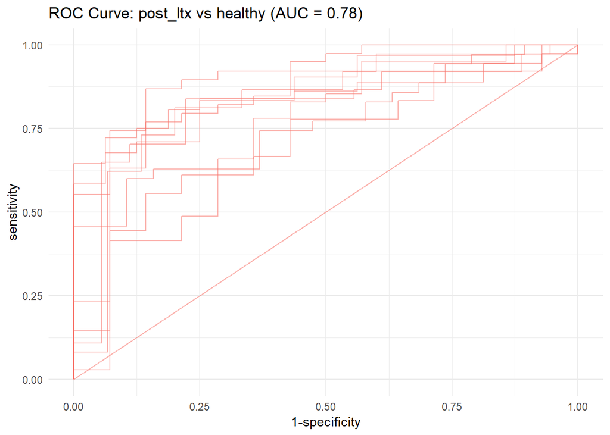

```r
roc_c
```

##### kNN

###### ASV level

```r
level="ASV"
```

*pre_ltx vs healthy*

```r
group <- c("pre_ltx","healthy")
comparison_name <- paste0(group[1], " vs ",group[2])
```

```r
model_name <- paste(comparison_name,level,segment)

# prepare the data
filt_ileum_uni_data <- binomial_prep(ileum_asv_tab,
                                     ileum_taxa_tab,
                                     ileum_metadata,
                                     group, usage="ml_ra")
```

```
## Removing 1478 ASV(s)
```

```
## Removing 118 ASV(s)
```

```r
# fit the model
knn_model <- knn_binomial(filt_ileum_uni_data,
                              sample_method = "atypboot",
                              outcome="Group",
                              N=10,
                              reuse=TRUE,
                              file=model_name,
                              Q="Q1_czech")

# ROC curve
roc_c <- roc_curve(knn_model, group)
# save the results
supplements_models[["models_summ"]][["knn_model_ra"]][[model_name]] <- knn_model$model_summary

supplements_models[["roc_cs"]][["knn_model_ra"]][[model_name]] <- knn_model$kfold_rocobjs

# see the results
knn_model$model_summary %>% t()
```

```
##                                       [,1]
## k                               11.0000000
## auc                              0.9110360
## auc_optimism_corrected           0.6990118
## auc_optimism_corrected_CIL       0.5201451
## auc_optimism_corrected_CIU       0.8744488
## accuracy                         0.6229508
## accuracy_optimism_corrected      0.5953868
## accuracy_optimism_corrected_CIL  0.4885093
## accuracy_optimism_corrected_CIU  0.7069805
```

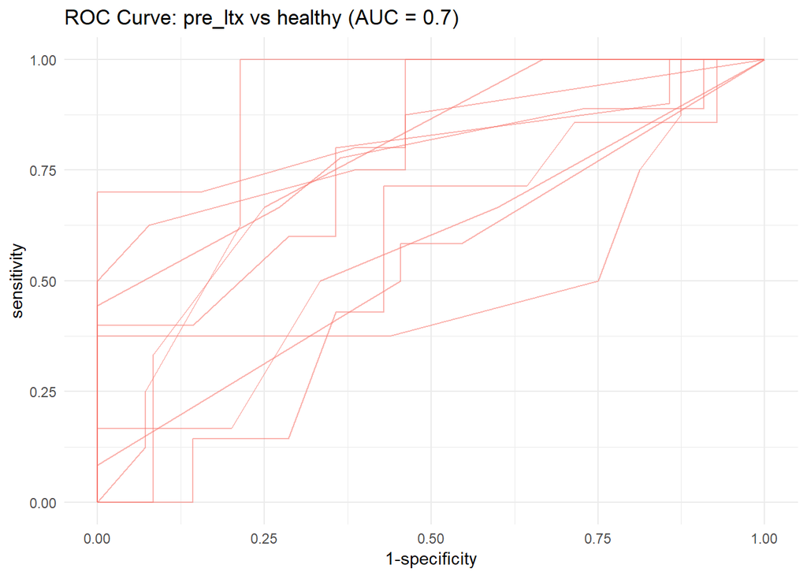

```r
roc_c
```

**pre_ltx vs post_ltx**

```r
group <- c("pre_ltx","post_ltx")
comparison_name <- paste0(group[1], " vs ",group[2])
```

```r
model_name <- paste(comparison_name,level,segment)

# prepare the data
filt_ileum_uni_data <- binomial_prep(ileum_asv_tab,
                                     ileum_taxa_tab,
                                     ileum_metadata,
                                     group, usage="ml_ra")
```

```
## Removing 555 ASV(s)
```

```
## Removing 36 ASV(s)
```

```r
# fit the model
knn_model <- knn_binomial(filt_ileum_uni_data,
                              sample_method = "atypboot",
                              outcome="Group",
                              N=10,
                              reuse=TRUE,
                              file=model_name,
                              Q="Q1_czech")

# ROC curve
roc_c <- roc_curve(knn_model, group)
# save the results
supplements_models[["models_summ"]][["knn_model_ra"]][[model_name]] <- knn_model$model_summary

supplements_models[["roc_cs"]][["knn_model_ra"]][[model_name]] <- knn_model$kfold_rocobjs

# see the results
knn_model$model_summary %>% t()
```

```
##                                       [,1]
## k                               10.0000000
## auc                              0.8588644
## auc_optimism_corrected           0.6665429
## auc_optimism_corrected_CIL       0.5741466
## auc_optimism_corrected_CIU       0.8298764
## accuracy                         0.8095238
## accuracy_optimism_corrected      0.7956747
## accuracy_optimism_corrected_CIL  0.7117021
## accuracy_optimism_corrected_CIU  0.8823266
```

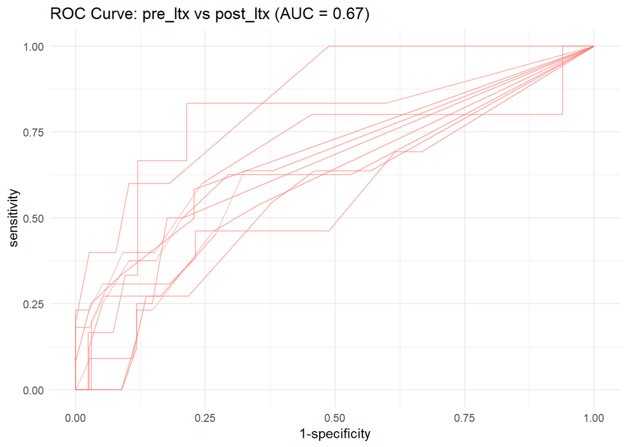

```r
roc_c
```

**post_ltx vs healthy**

```r
group <- c("post_ltx","healthy")
comparison_name <- paste0(group[1], " vs ",group[2])
```

```r
model_name <- paste(comparison_name,level,segment)

# prepare the data
filt_ileum_uni_data <- binomial_prep(ileum_asv_tab,
                                     ileum_taxa_tab,
                                     ileum_metadata,
                                     group, usage="ml_ra")
```

```
## Removing 260 ASV(s)
```

```
## Removing 48 ASV(s)
```

```r
# fit the model
knn_model <- knn_binomial(filt_ileum_uni_data,
                              sample_method = "atypboot",
                              outcome="Group",
                              N=10,
                              reuse=TRUE,
                              file=model_name,
                              Q="Q1_czech")

# ROC curve
roc_c <- roc_curve(knn_model, group)
# save the results
supplements_models[["models_summ"]][["knn_model_ra"]][[model_name]] <- knn_model$model_summary

supplements_models[["roc_cs"]][["knn_model_ra"]][[model_name]] <- knn_model$kfold_rocobjs

# see the results
knn_model$model_summary %>% t()
```

```
##                                       [,1]
## k                               15.0000000
## auc                              0.8180975
## auc_optimism_corrected           0.7040794
## auc_optimism_corrected_CIL       0.6010464
## auc_optimism_corrected_CIU       0.7911414
## accuracy                         0.8129496
## accuracy_optimism_corrected      0.7108628
## accuracy_optimism_corrected_CIL  0.6023514
## accuracy_optimism_corrected_CIU  0.7983019
```

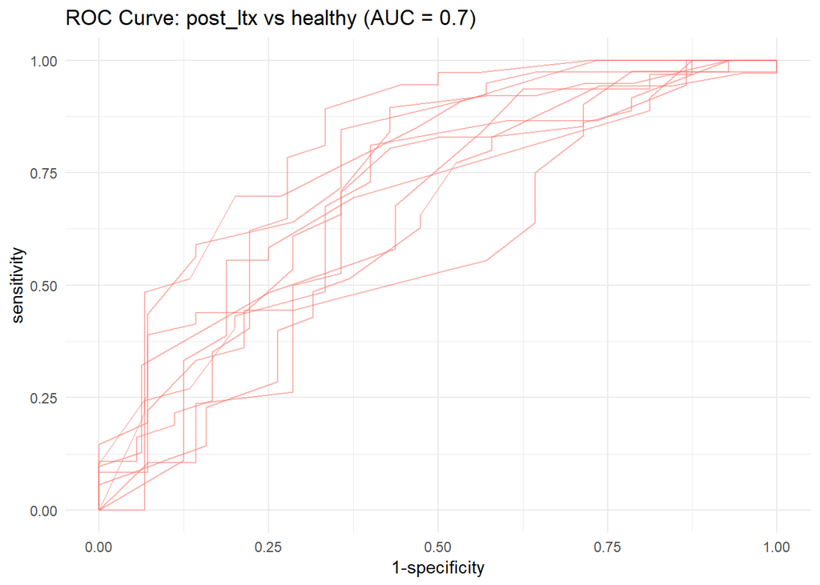

```r
roc_c
```

###### Genus level

```r
level="genus"
```

Aggregate taxa

```r
genus_data <- aggregate_taxa(ileum_asv_tab,
                             ileum_taxa_tab,
                             taxonomic_level = level)

ileum_genus_tab <- genus_data[[1]]
ileum_genus_taxa_tab <- genus_data[[2]]
```

**pre_ltx vs healthy**

```r
group <- c("pre_ltx","healthy")
comparison_name <- paste0(group[1], " vs ",group[2])
```

```r
model_name <- paste(comparison_name,level,segment)

# prepare the data
filt_ileum_uni_data <- binomial_prep(ileum_genus_tab,
                                     ileum_genus_taxa_tab,
                                     ileum_metadata,
                                     group,
                                     usage="ml_ra")
```

```
## Removing 93 ASV(s)
```

```
## Removing 8 ASV(s)
```

```r
# fit the model
knn_model <- knn_binomial(filt_ileum_uni_data,
                              sample_method = "atypboot",
                              outcome="Group",
                              N=10,
                              reuse=TRUE,
                              file=model_name,
                              Q="Q1_czech")

# ROC curve
roc_c <- roc_curve(knn_model, group)
# save the results
supplements_models[["models_summ"]][["knn_model_ra"]][[model_name]] <- knn_model$model_summary

supplements_models[["roc_cs"]][["knn_model_ra"]][[model_name]] <- knn_model$kfold_rocobjs

# see the results
knn_model$model_summary %>% t()
```

```
##                                       [,1]
## k                               10.0000000
## auc                              0.8023649
## auc_optimism_corrected           0.6724603
## auc_optimism_corrected_CIL       0.4564286
## auc_optimism_corrected_CIU       0.9615532
## accuracy                         0.6721311
## accuracy_optimism_corrected      0.6505327
## accuracy_optimism_corrected_CIL  0.5652174
## accuracy_optimism_corrected_CIU  0.7910173
```

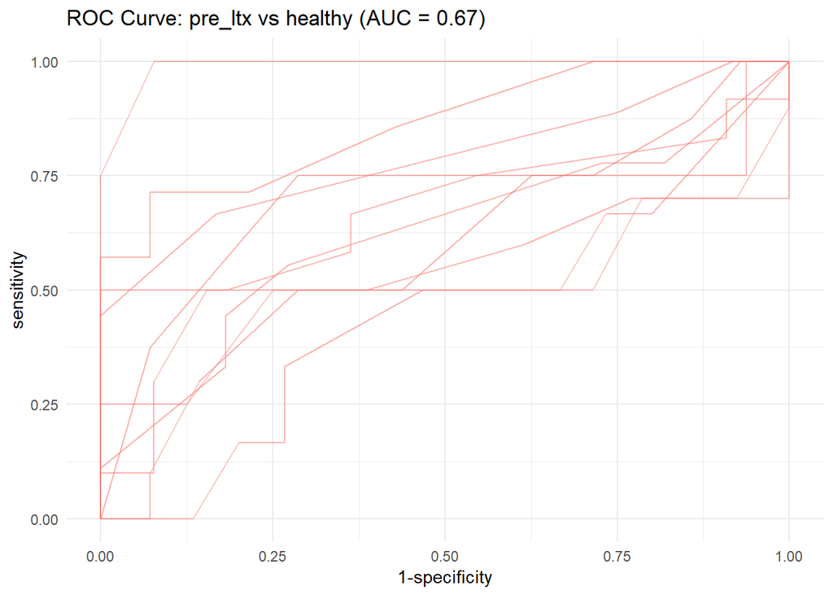

```r
roc_c
```

**pre_ltx vs post_ltx**

```r
group <- c("pre_ltx","post_ltx")
comparison_name <- paste0(group[1], " vs ",group[2])
```

```r
model_name <- paste(comparison_name,level,segment)

# prepare the data
filt_ileum_uni_data <- binomial_prep(ileum_genus_tab,
                                     ileum_genus_taxa_tab,
                                     ileum_metadata,
                                     group,
                                     usage="ml_ra")
```

```
## Removing 41 ASV(s)
```

```
## Removing 3 ASV(s)
```

```r
# fit the model
knn_model <- knn_binomial(filt_ileum_uni_data,
                              sample_method = "atypboot",
                              outcome="Group",
                              N=10,
                              reuse=TRUE,
                              file=model_name,
                              Q="Q1_czech")

# ROC curve
roc_c <- roc_curve(knn_model, group)
# save the results
supplements_models[["models_summ"]][["knn_model_ra"]][[model_name]] <- knn_model$model_summary

supplements_models[["roc_cs"]][["knn_model_ra"]][[model_name]] <- knn_model$kfold_rocobjs

# see the results
knn_model$model_summary %>% t()
```

```
##                                       [,1]
## k                               30.0000000
## auc                              0.7640931
## auc_optimism_corrected           0.5967148
## auc_optimism_corrected_CIL       0.4683710
## auc_optimism_corrected_CIU       0.6899451
## accuracy                         0.8095238
## accuracy_optimism_corrected      0.7987181
## accuracy_optimism_corrected_CIL  0.7281915
## accuracy_optimism_corrected_CIU  0.8823266
```

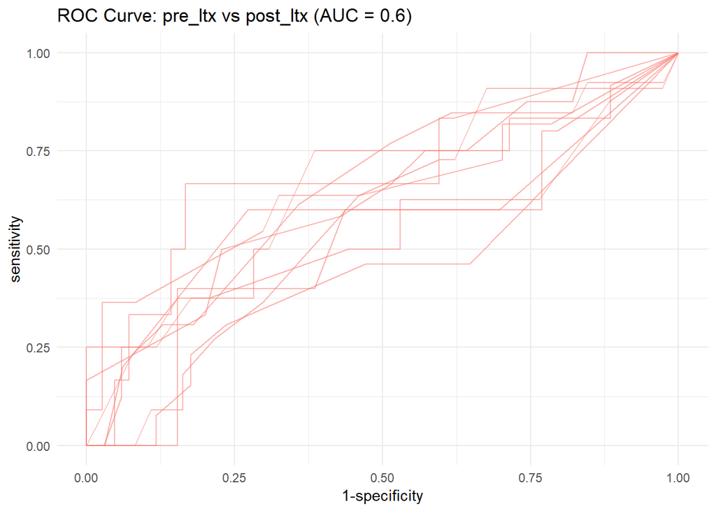

```r
roc_c
```

**post_ltx vs healthy**

```r
group <- c("post_ltx","healthy")
comparison_name <- paste0(group[1], " vs ",group[2])
```

```r
model_name <- paste(comparison_name,level,segment)

# prepare the data
filt_ileum_uni_data <- binomial_prep(ileum_genus_tab,
                                     ileum_genus_taxa_tab,
                                     ileum_metadata,
                                     group,
                                     usage="ml_ra")
```

```
## Removing 16 ASV(s)
```

```
## Removing 2 ASV(s)
```

```r
# fit the model
knn_model <- knn_binomial(filt_ileum_uni_data,
                              sample_method = "atypboot",
                              outcome="Group",
                              N=10,
                              reuse=TRUE,
                              file=model_name,
                              Q="Q1_czech")

# ROC curve
roc_c <- roc_curve(knn_model, group)
# save the results
supplements_models[["models_summ"]][["knn_model_ra"]][[model_name]] <- knn_model$model_summary

supplements_models[["roc_cs"]][["knn_model_ra"]][[model_name]] <- knn_model$kfold_rocobjs

# see the results
knn_model$model_summary %>% t()
```

```
##                                       [,1]
## k                               16.0000000
## auc                              0.8449921
## auc_optimism_corrected           0.7102435
## auc_optimism_corrected_CIL       0.5709124
## auc_optimism_corrected_CIU       0.7964627
## accuracy                         0.7985612
## accuracy_optimism_corrected      0.7138748
## accuracy_optimism_corrected_CIL  0.6218794
## accuracy_optimism_corrected_CIU  0.8138019
```

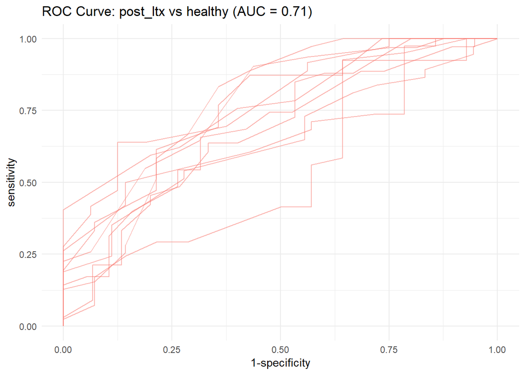

```r
roc_c
```

##### Random Forest

###### ASV level

```r
level="ASV"
```

*pre_ltx vs healthy*

```r
group <- c("pre_ltx","healthy")
comparison_name <- paste0(group[1], " vs ",group[2])
```

```r
model_name <- paste(comparison_name,level,segment)

# prepare the data
filt_ileum_uni_data <- binomial_prep(ileum_asv_tab,
                                     ileum_taxa_tab,
                                     ileum_metadata,
                                     group, usage="ml_ra")
```

```
## Removing 1478 ASV(s)
```

```
## Removing 118 ASV(s)
```

```r
# fit the model
rf_model <- rf_binomial(filt_ileum_uni_data,
                              sample_method = "atypboot",
                              outcome="Group",
                              N=10,
                              reuse=TRUE,
                              file=model_name,
                              Q="Q1_czech")

# ROC curve
roc_c <- roc_curve(rf_model, group)
# save the results
supplements_models[["models_summ"]][["rf_model_ra"]][[model_name]] <- rf_model$model_summary

supplements_models[["roc_cs"]][["rf_model_ra"]][[model_name]] <- rf_model$kfold_rocobjs

# see the results
rf_model$model_summary %>% t()
```

```
##                                 [,1]
## mtry                            "105"
## splitrule                       "gini"
## min.node.size                   "2"
## auc                             "1"
## auc_optimism_corrected          "0.9169639"
## auc_optimism_corrected_CIL      "0.7780303"
## auc_optimism_corrected_CIU      "0.9842147"
## accuracy                        "1"
## accuracy_optimism_corrected     "0.8188161"
## accuracy_optimism_corrected_CIL "0.6602717"
## accuracy_optimism_corrected_CIU "0.9047619"
```

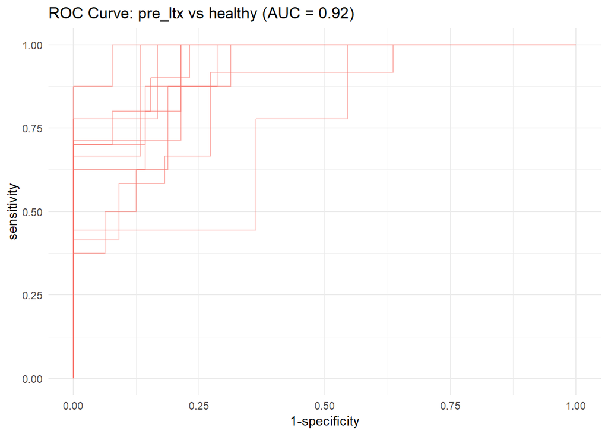

```r
roc_c
```

**pre_ltx vs post_ltx**

```r
group <- c("pre_ltx","post_ltx")
comparison_name <- paste0(group[1], " vs ",group[2])
```

```r
model_name <- paste(comparison_name,level,segment)

# prepare the data
filt_ileum_uni_data <- binomial_prep(ileum_asv_tab,
                                     ileum_taxa_tab,
                                     ileum_metadata,
                                     group, usage="ml_ra")
```

```
## Removing 555 ASV(s)
```

```
## Removing 36 ASV(s)
```

```r
# fit the model
rf_model <- rf_binomial(filt_ileum_uni_data,
                              sample_method = "atypboot",
                              outcome="Group",
                              N=10,
                              reuse=TRUE,
                              file=model_name,
                              Q="Q1_czech")

# ROC curve
roc_c <- roc_curve(rf_model, group)
# save the results
supplements_models[["models_summ"]][["rf_model_ra"]][[model_name]] <- rf_model$model_summary

supplements_models[["roc_cs"]][["rf_model_ra"]][[model_name]] <- rf_model$kfold_rocobjs


# see the results
rf_model$model_summary %>% t()
```

```
##                                 [,1]
## mtry                            "53"
## splitrule                       "gini"
## min.node.size                   "2"
## auc                             "1"
## auc_optimism_corrected          "0.7942196"
## auc_optimism_corrected_CIL      "0.6562306"
## auc_optimism_corrected_CIU      "0.8874175"
## accuracy                        "1"
## accuracy_optimism_corrected     "0.7986889"
## accuracy_optimism_corrected_CIL "0.7250614"
## accuracy_optimism_corrected_CIU "0.8673445"
```

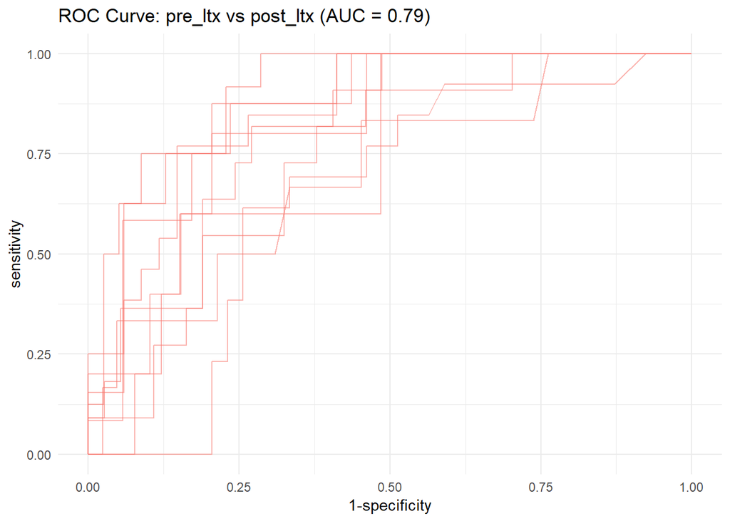

```r
roc_c
```

**post_ltx vs healthy**

```r
group <- c("post_ltx","healthy")
comparison_name <- paste0(group[1], " vs ",group[2])
```

```r
model_name <- paste(comparison_name,level,segment)

# prepare the data
filt_ileum_uni_data <- binomial_prep(ileum_asv_tab,
                                     ileum_taxa_tab,
                                     ileum_metadata,
                                     group, usage="ml_ra")
```

```
## Removing 260 ASV(s)
```

```
## Removing 48 ASV(s)
```

```r
# fit the model
rf_model <- rf_binomial(filt_ileum_uni_data,
                              sample_method = "atypboot",
                              outcome="Group",
                              N=10,
                              reuse=TRUE,
                              file=model_name,
                              Q="Q1_czech")

# ROC curve
roc_c <- roc_curve(rf_model, group)
# save the results
supplements_models[["models_summ"]][["rf_model_ra"]][[model_name]] <- rf_model$model_summary

supplements_models[["roc_cs"]][["rf_model_ra"]][[model_name]] <- rf_model$kfold_rocobjs


# see the results
rf_model$model_summary %>% t()
```

```
##                                 [,1]
## mtry                            "71"
## splitrule                       "gini"
## min.node.size                   "2"
## auc                             "1"
## auc_optimism_corrected          "0.9228307"
## auc_optimism_corrected_CIL      "0.8516193"
## auc_optimism_corrected_CIU      "0.9663803"
## accuracy                        "1"
## accuracy_optimism_corrected     "0.8354697"
## accuracy_optimism_corrected_CIL "0.8078764"
## accuracy_optimism_corrected_CIU "0.8776488"
```

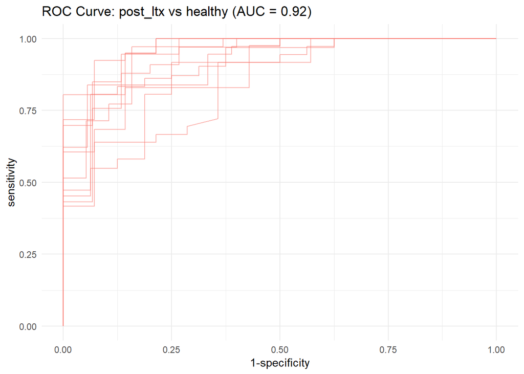

```r
roc_c
```

###### Genus level

```r
level="genus"
```

Aggregate taxa

```r
genus_data <- aggregate_taxa(ileum_asv_tab,
                             ileum_taxa_tab,
                             taxonomic_level = level)

ileum_genus_tab <- genus_data[[1]]
ileum_genus_taxa_tab <- genus_data[[2]]
```

**pre_ltx vs healthy**

```r
group <- c("pre_ltx","healthy")
comparison_name <- paste0(group[1], " vs ",group[2])
```

```r
model_name <- paste(comparison_name,level,segment)

# prepare the data
filt_ileum_uni_data <- binomial_prep(ileum_genus_tab,
                                     ileum_genus_taxa_tab,
                                     ileum_metadata,
                                     group,
                                     usage="ml_ra")
```

```
## Removing 93 ASV(s)
```

```
## Removing 8 ASV(s)
```

```r
# fit the model
rf_model <- rf_binomial(filt_ileum_uni_data,
                              sample_method = "atypboot",
                              outcome="Group",
                              N=10,
                              reuse=TRUE,
                              file=model_name,
                              Q="Q1_czech")

# ROC curve
roc_c <- roc_curve(rf_model, group)
# save the results
supplements_models[["models_summ"]][["rf_model_ra"]][[model_name]] <- rf_model$model_summary

supplements_models[["roc_cs"]][["rf_model_ra"]][[model_name]] <- rf_model$kfold_rocobjs


# see the results
rf_model$model_summary %>% t()
```

```
##                                 [,1]
## mtry                            "93"
## splitrule                       "gini"
## min.node.size                   "2"
## auc                             "1"
## auc_optimism_corrected          "0.9215987"
## auc_optimism_corrected_CIL      "0.8507365"
## auc_optimism_corrected_CIU      "0.9755298"
## accuracy                        "1"
## accuracy_optimism_corrected     "0.8093709"
## accuracy_optimism_corrected_CIL "0.7078804"
## accuracy_optimism_corrected_CIU "0.8724432"
```

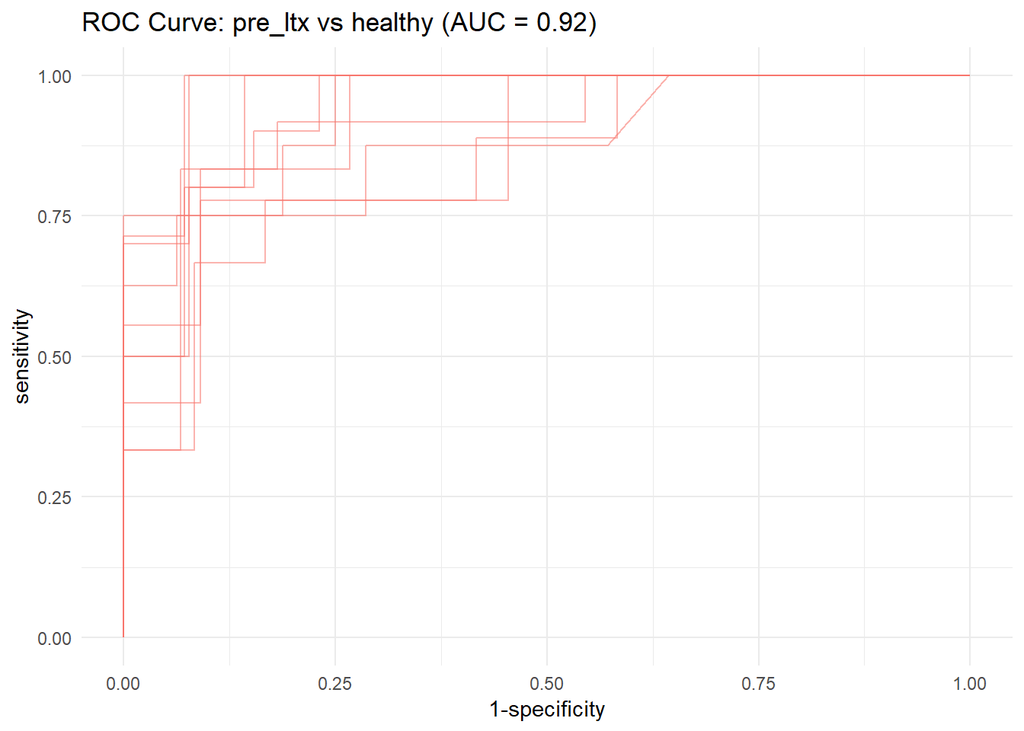

```r
roc_c
```

**pre_ltx vs post_ltx**

```r
group <- c("pre_ltx","post_ltx")
comparison_name <- paste0(group[1], " vs ",group[2])
```

```r
model_name <- paste(comparison_name,level,segment)

# prepare the data
filt_ileum_uni_data <- binomial_prep(ileum_genus_tab,
                                     ileum_genus_taxa_tab,
                                     ileum_metadata,
                                     group,
                                     usage="ml_ra")
```

```
## Removing 41 ASV(s)
```

```
## Removing 3 ASV(s)
```

```r
# fit the model
rf_model <- rf_binomial(filt_ileum_uni_data,
                              sample_method = "atypboot",
                              outcome="Group",
                              N=10,
                              reuse=TRUE,
                              file=model_name,
                              Q="Q1_czech")

# ROC curve
roc_c <- roc_curve(rf_model, group)
# save the results
supplements_models[["models_summ"]][["rf_model_ra"]][[model_name]] <- rf_model$model_summary

supplements_models[["roc_cs"]][["rf_model_ra"]][[model_name]] <- rf_model$kfold_rocobjs


# see the results
rf_model$model_summary %>% t()
```

```
##                                 [,1]
## mtry                            "29"
## splitrule                       "gini"
## min.node.size                   "2"
## auc                             "1"
## auc_optimism_corrected          "0.7494602"
## auc_optimism_corrected_CIL      "0.6336292"
## auc_optimism_corrected_CIU      "0.8452175"
## accuracy                        "1"
## accuracy_optimism_corrected     "0.7778113"
## accuracy_optimism_corrected_CIL "0.7247008"
## accuracy_optimism_corrected_CIU "0.8673445"
```

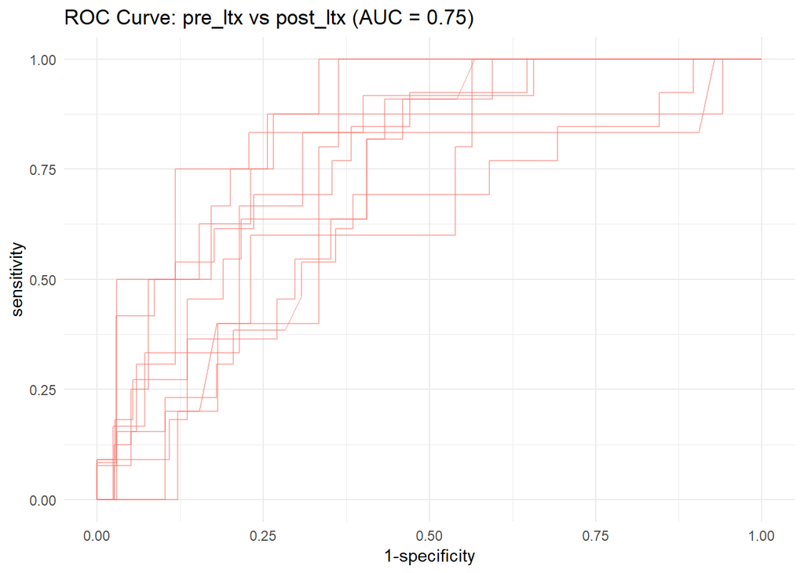

```r
roc_c
```

**post_ltx vs healthy**

```r
group <- c("post_ltx","healthy")
comparison_name <- paste0(group[1], " vs ",group[2])
```

```r
model_name <- paste(comparison_name,level,segment)

# prepare the data
filt_ileum_uni_data <- binomial_prep(ileum_genus_tab,
                                     ileum_genus_taxa_tab,
                                     ileum_metadata,
                                     group,
                                     usage="ml_ra")
```

```
## Removing 16 ASV(s)
```

```
## Removing 2 ASV(s)
```

```r
# fit the model
rf_model <- rf_binomial(filt_ileum_uni_data,
                              sample_method = "atypboot",
                              outcome="Group",
                              N=10,
                              reuse=TRUE,
                              file=model_name,
                              Q="Q1_czech")

# ROC curve
roc_c <- roc_curve(rf_model, group)
# save the results
supplements_models[["models_summ"]][["rf_model_ra"]][[model_name]] <- rf_model$model_summary

supplements_models[["roc_cs"]][["rf_model_ra"]][[model_name]] <- rf_model$kfold_rocobjs


# see the results
rf_model$model_summary %>% t()
```

```
##                                 [,1]
## mtry                            "109"
## splitrule                       "gini"
## min.node.size                   "2"
## auc                             "1"
## auc_optimism_corrected          "0.8691973"
## auc_optimism_corrected_CIL      "0.7834489"
## auc_optimism_corrected_CIU      "0.9416474"
## accuracy                        "1"
## accuracy_optimism_corrected     "0.8255819"
## accuracy_optimism_corrected_CIL "0.7641586"
## accuracy_optimism_corrected_CIU "0.9079108"
```

```r
roc_c
```

##### Gradient boosting

###### ASV level

```r
level="ASV"
```

*pre_ltx vs healthy*

```r
group <- c("pre_ltx","healthy")
comparison_name <- paste0(group[1], " vs ",group[2])
```

```r
model_name <- paste(comparison_name,level,segment)

# prepare the data
filt_ileum_uni_data <- binomial_prep(ileum_asv_tab,
                                     ileum_taxa_tab,
                                     ileum_metadata,
                                     group, usage="ml_ra")
```

```
## Removing 1478 ASV(s)
```

```
## Removing 118 ASV(s)
```

```r
# fit the model
gbm_model <- gbm_binomial(filt_ileum_uni_data,
                              sample_method = "atypboot",
                              outcome="Group",
                              N=10,
                              reuse=TRUE,
                              file=model_name,
                              Q="Q1_czech")

# ROC curve
roc_c <- roc_curve(gbm_model, group)
# save the results
supplements_models[["models_summ"]][["gbm_model_ra"]][[model_name]] <- gbm_model$model_summary

supplements_models[["roc_cs"]][["gbm_model_ra"]][[model_name]] <- gbm_model$kfold_rocobjs

# see the results
gbm_model$model_summary %>% t()
```

```
##                                 [,1]
## mtry                            "109"
## splitrule                       "gini"
## min.node.size                   "2"
## auc                             "1"
## auc_optimism_corrected          "0.8691973"
## auc_optimism_corrected_CIL      "0.7834489"
## auc_optimism_corrected_CIU      "0.9416474"
## accuracy                        "1"
## accuracy_optimism_corrected     "0.8255819"
## accuracy_optimism_corrected_CIL "0.7641586"
## accuracy_optimism_corrected_CIU "0.9079108"
```

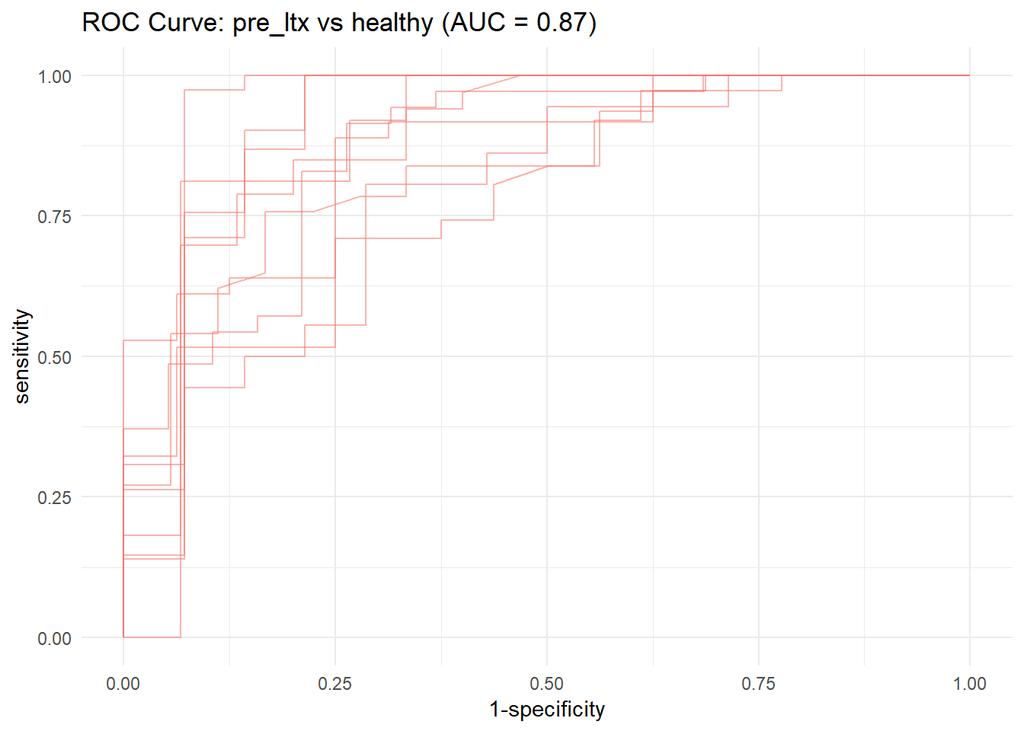

```r
roc_c
```

**pre_ltx vs post_ltx**

```r
group <- c("pre_ltx","post_ltx")
comparison_name <- paste0(group[1], " vs ",group[2])
```

```r
model_name <- paste(comparison_name,level,segment)

# prepare the data
filt_ileum_uni_data <- binomial_prep(ileum_asv_tab,
                                     ileum_taxa_tab,
                                     ileum_metadata,
                                     group, usage="ml_ra")
```

```
## Removing 555 ASV(s)
```

```
## Removing 36 ASV(s)
```

```r
# fit the model
gbm_model <- gbm_binomial(filt_ileum_uni_data,
                              sample_method = "atypboot",
                              outcome="Group",
                              N=10,
                              reuse=TRUE,
                              file=model_name,
                              Q="Q1_czech")

# ROC curve
roc_c <- roc_curve(gbm_model, group)
# save the results
supplements_models[["models_summ"]][["gbm_model_ra"]][[model_name]] <- gbm_model$model_summary

supplements_models[["roc_cs"]][["gbm_model_ra"]][[model_name]] <- gbm_model$kfold_rocobjs

# see the results
gbm_model$model_summary %>% t()
```

```
##                                 [,1]
## mtry                            "109"
## splitrule                       "gini"
## min.node.size                   "2"
## auc                             "1"
## auc_optimism_corrected          "0.8691973"
## auc_optimism_corrected_CIL      "0.7834489"
## auc_optimism_corrected_CIU      "0.9416474"
## accuracy                        "1"
## accuracy_optimism_corrected     "0.8255819"
## accuracy_optimism_corrected_CIL "0.7641586"
## accuracy_optimism_corrected_CIU "0.9079108"
```

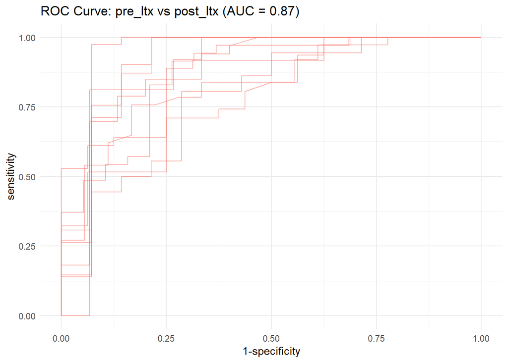

```r
roc_c
```

**post_ltx vs healthy**

```r
group <- c("post_ltx","healthy")
comparison_name <- paste0(group[1], " vs ",group[2])
```

```r
model_name <- paste(comparison_name,level,segment)

# prepare the data
filt_ileum_uni_data <- binomial_prep(ileum_asv_tab,
                                     ileum_taxa_tab,
                                     ileum_metadata,
                                     group, usage="ml_ra")
```

```
## Removing 260 ASV(s)
```

```
## Removing 48 ASV(s)
```

```r
# fit the model
gbm_model <- gbm_binomial(filt_ileum_uni_data,
                              sample_method = "atypboot",
                              outcome="Group",
                              N=10,
                              reuse=TRUE,
                              file=model_name,
                              Q="Q1_czech")

# ROC curve
roc_c <- roc_curve(gbm_model, group)
# save the results
supplements_models[["models_summ"]][["gbm_model_ra"]][[model_name]] <- gbm_model$model_summary

supplements_models[["roc_cs"]][["gbm_model_ra"]][[model_name]] <- gbm_model$kfold_rocobjs

# see the results
gbm_model$model_summary %>% t()
```

```
##                                 [,1]
## mtry                            "109"
## splitrule                       "gini"
## min.node.size                   "2"
## auc                             "1"
## auc_optimism_corrected          "0.8691973"
## auc_optimism_corrected_CIL      "0.7834489"
## auc_optimism_corrected_CIU      "0.9416474"
## accuracy                        "1"
## accuracy_optimism_corrected     "0.8255819"
## accuracy_optimism_corrected_CIL "0.7641586"
## accuracy_optimism_corrected_CIU "0.9079108"
```

```r
roc_c
```

###### Genus level

```r
level="genus"
```

Aggregate taxa

```r
genus_data <- aggregate_taxa(ileum_asv_tab,
                             ileum_taxa_tab,
                             taxonomic_level = level)

ileum_genus_tab <- genus_data[[1]]
ileum_genus_taxa_tab <- genus_data[[2]]
```

**pre_ltx vs healthy**

```r
group <- c("pre_ltx","healthy")
comparison_name <- paste0(group[1], " vs ",group[2])
```

```r
model_name <- paste(comparison_name,level,segment)

# prepare the data
filt_ileum_uni_data <- binomial_prep(ileum_genus_tab,
                                     ileum_genus_taxa_tab,
                                     ileum_metadata,
                                     group,
                                     usage="ml_ra")
```

```
## Removing 93 ASV(s)
```

```
## Removing 8 ASV(s)
```

```r
# fit the model
gbm_model <- gbm_binomial(filt_ileum_uni_data,
                              sample_method = "atypboot",
                              outcome="Group",
                              N=10,
                              reuse=TRUE,
                              file=model_name,
                              Q="Q1_czech")

# ROC curve
roc_c <- roc_curve(gbm_model, group)
# save the results
supplements_models[["models_summ"]][["gbm_model_ra"]][[model_name]] <- gbm_model$model_summary

supplements_models[["roc_cs"]][["gbm_model_ra"]][[model_name]] <- gbm_model$kfold_rocobjs

# see the results
gbm_model$model_summary %>% t()
```

```
##                                 [,1]
## mtry                            "109"
## splitrule                       "gini"
## min.node.size                   "2"
## auc                             "1"
## auc_optimism_corrected          "0.8691973"
## auc_optimism_corrected_CIL      "0.7834489"
## auc_optimism_corrected_CIU      "0.9416474"
## accuracy                        "1"
## accuracy_optimism_corrected     "0.8255819"
## accuracy_optimism_corrected_CIL "0.7641586"
## accuracy_optimism_corrected_CIU "0.9079108"
```

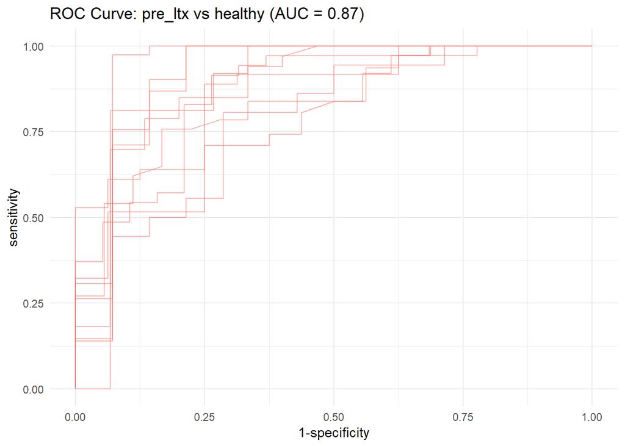

```r
roc_c
```

**pre_ltx vs post_ltx**

```r
group <- c("pre_ltx","post_ltx")
comparison_name <- paste0(group[1], " vs ",group[2])
```

```r
model_name <- paste(comparison_name,level,segment)

# prepare the data
filt_ileum_uni_data <- binomial_prep(ileum_genus_tab,
                                     ileum_genus_taxa_tab,
                                     ileum_metadata,
                                     group,
                                     usage="ml_ra")
```

```
## Removing 41 ASV(s)
```

```
## Removing 3 ASV(s)
```

```r
# fit the model
gbm_model <- gbm_binomial(filt_ileum_uni_data,
                              sample_method = "atypboot",
                              outcome="Group",
                              N=10,
                              reuse=TRUE,
                              file=model_name,
                              Q="Q1_czech")

# ROC curve
roc_c <- roc_curve(gbm_model, group)
# save the results
supplements_models[["models_summ"]][["gbm_model_ra"]][[model_name]] <- gbm_model$model_summary

supplements_models[["roc_cs"]][["gbm_model_ra"]][[model_name]] <- gbm_model$kfold_rocobjs

# see the results
gbm_model$model_summary %>% t()
```

```
##                                 [,1]
## mtry                            "109"
## splitrule                       "gini"
## min.node.size                   "2"
## auc                             "1"
## auc_optimism_corrected          "0.8691973"
## auc_optimism_corrected_CIL      "0.7834489"
## auc_optimism_corrected_CIU      "0.9416474"
## accuracy                        "1"
## accuracy_optimism_corrected     "0.8255819"
## accuracy_optimism_corrected_CIL "0.7641586"
## accuracy_optimism_corrected_CIU "0.9079108"
```

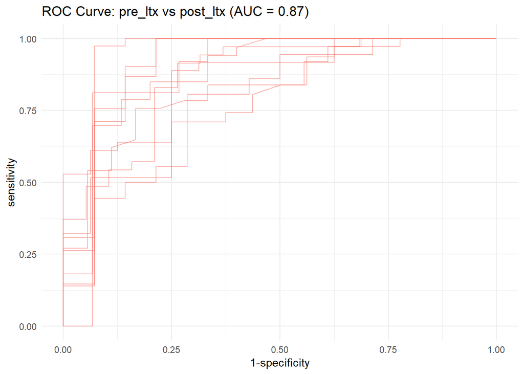

```r
roc_c
```

**post_ltx vs healthy**

```r
group <- c("post_ltx","healthy")
comparison_name <- paste0(group[1], " vs ",group[2])
```

```r
model_name <- paste(comparison_name,level,segment)

# prepare the data
filt_ileum_uni_data <- binomial_prep(ileum_genus_tab,
                                     ileum_genus_taxa_tab,
                                     ileum_metadata,
                                     group,
                                     usage="ml_ra")
```

```
## Removing 16 ASV(s)
```

```
## Removing 2 ASV(s)
```

```r
# fit the model
gbm_model <- gbm_binomial(filt_ileum_uni_data,
                              sample_method = "atypboot",
                              outcome="Group",
                              N=10,
                              reuse=TRUE,
                              file=model_name,
                              Q="Q1_czech")

# ROC curve
roc_c <- roc_curve(gbm_model, group)
# save the results
supplements_models[["models_summ"]][["gbm_model_ra"]][[model_name]] <- gbm_model$model_summary

supplements_models[["roc_cs"]][["gbm_model_ra"]][[model_name]] <- gbm_model$kfold_rocobjs

# see the results
gbm_model$model_summary %>% t()
```

```
##                                 [,1]
## mtry                            "109"
## splitrule                       "gini"
## min.node.size                   "2"
## auc                             "1"
## auc_optimism_corrected          "0.8691973"
## auc_optimism_corrected_CIL      "0.7834489"
## auc_optimism_corrected_CIU      "0.9416474"
## accuracy                        "1"
## accuracy_optimism_corrected     "0.8255819"
## accuracy_optimism_corrected_CIL "0.7641586"
## accuracy_optimism_corrected_CIU "0.9079108"
```

```r
roc_c
```

#### Saving results

```r
models_list <- list()

for (model_name in names(supplements_models$models_summ)){
  df <- do.call(rbind, supplements_models$models_summ[[model_name]])
  models_list[[model_name]] <- df
}

write.xlsx(models_list,
           file=file.path(path,paste0("supplements_models_",segment,".xlsx")),
           rowNames=TRUE)
```

## Results overview

#### Alpha diversity

```r
pc_observed[[segment]]
```

|  | Estimate | Std..Error | t.value | Pr...t.. | p.adj | sig |
| --- | --- | --- | --- | --- | --- | --- |
| healthy vs Grouppre_ltx | -53.26689 | 12.975688 | -4.105131 | 0.0001259684 | 0.0003779053 | *** |
| pre_ltx vs Grouppost_ltx | 25.12010 | 11.755098 | 2.136953 | 0.0345657163 | 0.0345657163 | * |
| healthy vs Grouppost_ltx | -28.14679 | 9.268876 | -3.036700 | 0.0028640459 | 0.0042960689 | ** |

```r
pc_shannon[[segment]]
```

|  | Estimate | Std..Error | t.value | Pr...t.. | p.adj | sig |
| --- | --- | --- | --- | --- | --- | --- |
| healthy vs Grouppre_ltx | -0.5057628 | 0.1747512 | -2.894188 | 0.005320181 | 0.01596054 | * |
| pre_ltx vs Grouppost_ltx | 0.3717782 | 0.1474762 | 2.520938 | 0.012972935 | 0.01945940 | * |
| healthy vs Grouppost_ltx | -0.1339846 | 0.1101184 | -1.216732 | 0.225798210 | 0.22579821 |  |

```r
pc_simpson[[segment]]
```

|  | Estimate | Std..Error | t.value | Pr...t.. | p.adj | sig |
| --- | --- | --- | --- | --- | --- | --- |
| healthy vs Grouppre_ltx | -0.046708759 | 0.01997279 | -2.3386202 | 0.02276302 | 0.06828905 |  |
| pre_ltx vs Grouppost_ltx | 0.037478257 | 0.02110624 | 1.7756960 | 0.07823601 | 0.11735402 |  |
| healthy vs Grouppost_ltx | -0.009230502 | 0.01599206 | -0.5771929 | 0.56475642 | 0.56475642 |  |

```r
pc_pielou[[segment]]
```

|  | Estimate | Std..Error | t.value | Pr...t.. | p.adj | sig |
| --- | --- | --- | --- | --- | --- | --- |
| healthy vs Grouppre_ltx | -0.041610977 | 0.02490879 | -1.67053369 | 0.10011103 | 0.1501665 |  |
| pre_ltx vs Grouppost_ltx | 0.042950906 | 0.02134350 | 2.01236472 | 0.04634809 | 0.1390443 |  |
| healthy vs Grouppost_ltx | 0.001339929 | 0.01690592 | 0.07925798 | 0.93694308 | 0.9369431 |  |

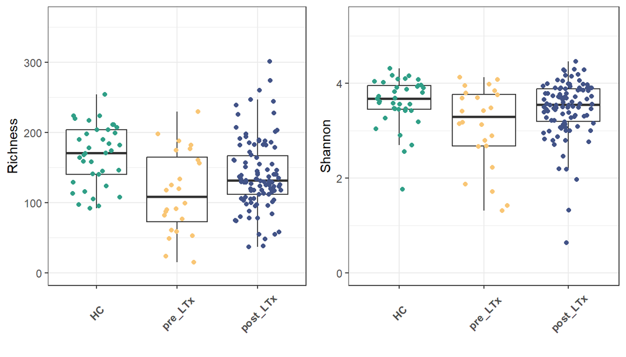

```r
alpha_div_plots[[paste(segment,"Custom")]]
```

#### Beta diversity

**Main results**

```r
pairwise_aitchison_raw[[paste("genus", segment)]]
```

| pairs | Df | SumsOfSqs | F.Model | R2 | p.value | p.adjusted | sig |
| --- | --- | --- | --- | --- | --- | --- | --- |
| pre_ltx vs healthy | 1 | 285.0316 | 1.704880 | 0.028084728 | 0.002 | 0.003 | ** |
| pre_ltx vs post_ltx | 1 | 192.7236 | 1.059177 | 0.008469408 | 0.305 | 0.305 |  |
| post_ltx vs healthy | 1 | 488.8222 | 2.712476 | 0.019414702 | 0.001 | 0.003 | ** |

PCA

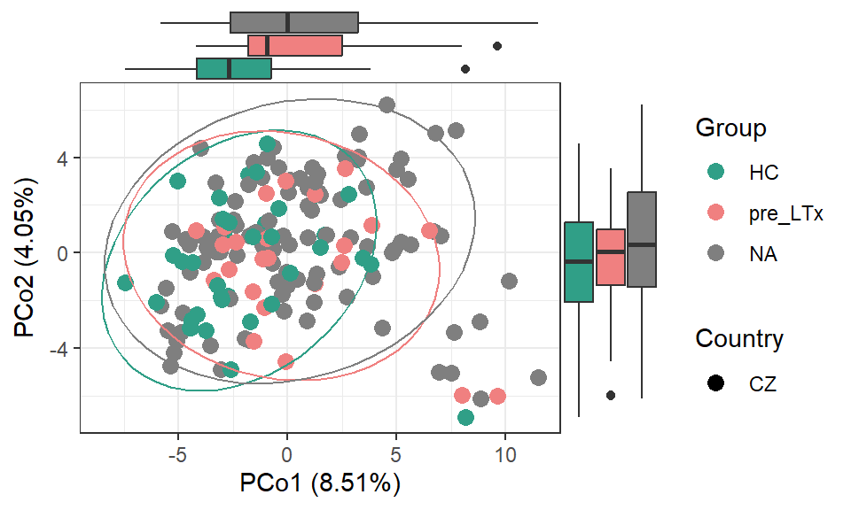

```r
pca_plots_list[[paste(segment,"genus custom")]]
```

**Supplements**

```r
knitr::kable(supplements_beta[!grepl("PCoA",names(supplements_beta))],
             digits = 3,
             caption = "Supplementary PERMANOVA results")
```

Supplementary PERMANOVA results

| pairs | Df | SumsOfSqs | F.Model | R2 | p.value | p.adjusted | sig |
| --- | --- | --- | --- | --- | --- | --- | --- |
| pre_ltx vs healthy | 1 | 0.412 | 2.198 | 0.036 | 0.008 | 0.012 | * |
| pre_ltx vs post_ltx | 1 | 0.230 | 1.052 | 0.008 | 0.350 | 0.350 |  |
| post_ltx vs healthy | 1 | 0.771 | 3.752 | 0.027 | 0.001 | 0.003 | ** |

| pairs | Df | SumsOfSqs | F.Model | R2 | p.value | p.adjusted | sig |
| --- | --- | --- | --- | --- | --- | --- | --- |
| pre_ltx vs healthy | 1 | 0.499 | 1.835 | 0.030 | 0.005 | 0.007 | ** |
| pre_ltx vs post_ltx | 1 | 0.333 | 1.101 | 0.009 | 0.262 | 0.262 |  |
| post_ltx vs healthy | 1 | 0.865 | 2.980 | 0.021 | 0.001 | 0.003 | ** |

| pairs | Df | SumsOfSqs | F.Model | R2 | p.value | p.adjusted | sig |
| --- | --- | --- | --- | --- | --- | --- | --- |
| pre_ltx vs healthy | 1 | 484.192 | 1.552 | 0.026 | 0.002 | 0.003 | ** |
| pre_ltx vs post_ltx | 1 | 320.395 | 1.130 | 0.009 | 0.121 | 0.121 |  |
| post_ltx vs healthy | 1 | 877.994 | 2.987 | 0.021 | 0.001 | 0.003 | ** |

| pairs | Df | SumsOfSqs | F.Model | R2 | p.value | p.adjusted | sig |
| --- | --- | --- | --- | --- | --- | --- | --- |
| pre_ltx vs healthy | 1 | 0.566 | 1.748 | 0.029 | 0.007 | 0.011 | * |
| pre_ltx vs post_ltx | 1 | 0.437 | 1.284 | 0.010 | 0.113 | 0.113 |  |
| post_ltx vs healthy | 1 | 1.212 | 3.689 | 0.026 | 0.001 | 0.003 | ** |

| pairs | Df | SumsOfSqs | F.Model | R2 | p.value | p.adjusted | sig |
| --- | --- | --- | --- | --- | --- | --- | --- |
| pre_ltx vs healthy | 1 | 0.558 | 1.423 | 0.024 | 0.008 | 0.012 | * |
| pre_ltx vs post_ltx | 1 | 0.474 | 1.174 | 0.009 | 0.102 | 0.102 |  |
| post_ltx vs healthy | 1 | 1.027 | 2.597 | 0.019 | 0.001 | 0.003 | ** |

PCA

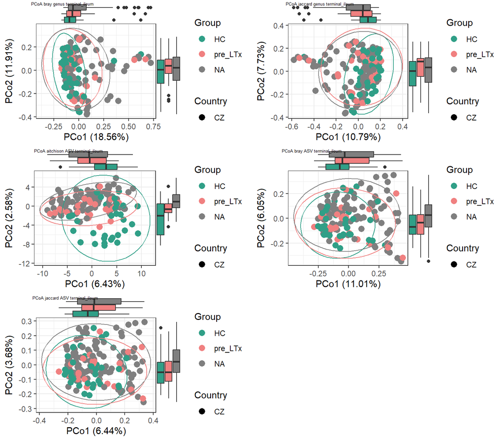

```r
ggarrange(plotlist = supplements_beta[grepl("PCoA",names(supplements_beta))],
          labels=names(supplements_beta[grepl("PCoA",names(supplements_beta))]),
          font.label = list(size=5,face="plain"),
          ncol=2,nrow=3)
```

#### Univariate analysis

**Number of significant taxa**

```r
knitr::kable(cbind(as.data.frame(lapply(list_intersections,nrow)),
      as.data.frame(lapply(psc_effect,nrow))) %>% t() %>%
  `colnames<-`("Count") %>%
  `rownames<-`(c(names(list_intersections),"PSC effect ASV","PSC effect Genus","PSC effect Phylum")),caption="Number of significant taxa")
```

Number of significant taxa

|  | Count |
| --- | --- |
| terminal_ileum genus healthy vs pre_ltx | 23 |
| terminal_ileum genus pre_ltx vs post_ltx | 6 |
| terminal_ileum genus healthy vs post_ltx | 31 |
| terminal_ileum ASV healthy vs pre_ltx | 27 |
| terminal_ileum ASV pre_ltx vs post_ltx | 3 |
| terminal_ileum ASV healthy vs post_ltx | 76 |
| terminal_ileum phylum healthy vs pre_ltx | 1 |
| terminal_ileum phylum pre_ltx vs post_ltx | 0 |
| terminal_ileum phylum healthy vs post_ltx | 2 |
| PSC effect ASV | 12 |
| PSC effect Genus | 18 |
| PSC effect Phylum | 0 |

#### Machine learning

**Main models**

Summary

```r
knitr::kable(models_summ_df_ileum %>% dplyr::select(
"alpha","lambda",
"auc_optimism_corrected",
"auc_optimism_corrected_CIL",
"auc_optimism_corrected_CIU"),
             digits=2,caption="Elastic net results")
```

Elastic net results

|  | alpha | lambda | auc_optimism_corrected | auc_optimism_corrected_CIL | auc_optimism_corrected_CIU |
| --- | --- | --- | --- | --- | --- |
| pre_ltx vs healthy ASV terminal_ileum | 0.0 | 4.43 | 0.91 | 0.75 | 0.97 |
| pre_ltx vs post_ltx ASV terminal_ileum | 0.0 | 23.62 | 0.69 | 0.58 | 0.81 |
| post_ltx vs healthy ASV terminal_ileum | 0.4 | 0.04 | 0.94 | 0.90 | 0.99 |
| pre_ltx vs healthy genus terminal_ileum | 0.2 | 0.16 | 0.91 | 0.85 | 1.00 |
| pre_ltx vs post_ltx genus terminal_ileum | 0.0 | 4.87 | 0.71 | 0.63 | 0.83 |
| post_ltx vs healthy genus terminal_ileum | 0.4 | 0.03 | 0.95 | 0.92 | 0.99 |

**ROC - ASV level**

```
## [1] "pre_ltx vs healthy ASV terminal_ileum"  "pre_ltx vs post_ltx ASV terminal_ileum"
## [3] "post_ltx vs healthy ASV terminal_ileum"
```

[output not shown]

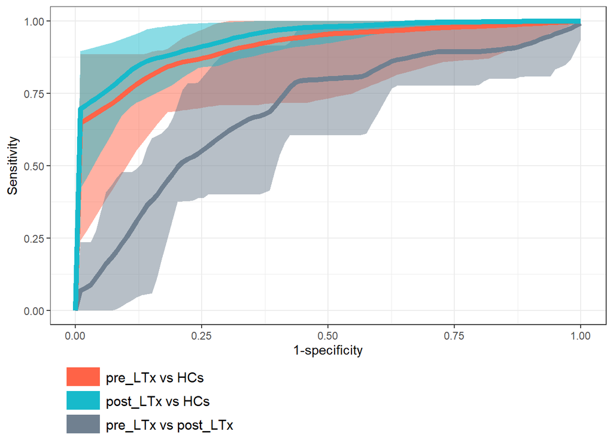

```r
roc_curve_all_custom(roc_cs[c(1:3)],
                     Q="Q1_czech",
                     model_name="enet_model")
```

**ROC - Genus level**

```
## [1] "pre_ltx vs healthy genus terminal_ileum"  "pre_ltx vs post_ltx genus terminal_ileum"
## [3] "post_ltx vs healthy genus terminal_ileum"
```

[output not shown]

[output cut: 21 more lines]

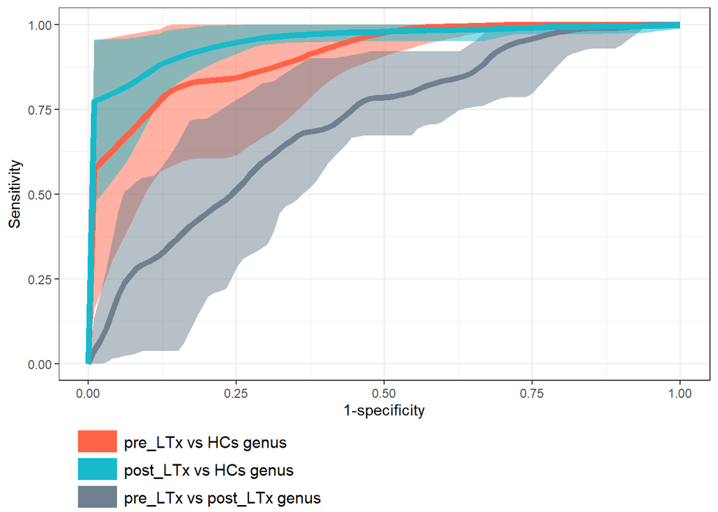

```r
roc_curve_all_custom(roc_cs[c(4:6)],Q="Q1_czech",
                     model_name="enet_model")
```

**Supplementary models**

Summary

```r
# Build final dataframe
models_list[["enet_model"]] <- models_summ_df_ileum
final_df <- tibble(row_names = rownames(models_list[[1]]))

# Loop through models and extract required values
for (model_name in names(models_list)) {
  model_df <- models_list[[model_name]]

  # Combine AUC_optimism_corrected with its CI values
  final_df[[model_name]] <- paste0(
    round(model_df$auc_optimism_corrected, 3),
    " (", round(model_df$auc_optimism_corrected_CIL, 3), "; ",
    round(model_df$auc_optimism_corrected_CIU, 3), ")"
  )
}

knitr::kable(final_df, caption="All models")
```

All models

| row_names | knn_model | rf_model | gbm_model | enet_model_ra | knn_model_ra | rf_model_ra | gbm_model_ra | enet_model |
| --- | --- | --- | --- | --- | --- | --- | --- | --- |
| pre_ltx vs healthy ASV terminal_ileum | 0.911 (0.846; 0.967) | 0.829 (0.577; 0.984) | 0.853 (0.72; 0.927) | 0.845 (0.706; 0.944) | 0.699 (0.52; 0.874) | 0.917 (0.778; 0.984) | 0.869 (0.783; 0.942) | 0.913 (0.746; 0.972) |
| pre_ltx vs post_ltx ASV terminal_ileum | 0.677 (0.585; 0.787) | 0.656 (0.578; 0.735) | 0.853 (0.72; 0.927) | 0.565 (0.372; 0.822) | 0.667 (0.574; 0.83) | 0.794 (0.656; 0.887) | 0.869 (0.783; 0.942) | 0.695 (0.582; 0.811) |
| post_ltx vs healthy ASV terminal_ileum | 0.818 (0.705; 0.952) | 0.865 (0.747; 0.948) | 0.853 (0.72; 0.927) | 0.795 (0.708; 0.869) | 0.704 (0.601; 0.791) | 0.923 (0.852; 0.966) | 0.869 (0.783; 0.942) | 0.942 (0.901; 0.986) |
| pre_ltx vs healthy genus terminal_ileum | 0.858 (0.791; 0.971) | 0.882 (0.769; 0.963) | 0.853 (0.72; 0.927) | 0.851 (0.744; 0.983) | 0.672 (0.456; 0.962) | 0.922 (0.851; 0.976) | 0.869 (0.783; 0.942) | 0.913 (0.849; 0.996) |
| pre_ltx vs post_ltx genus terminal_ileum | 0.693 (0.559; 0.805) | 0.708 (0.503; 0.863) | 0.853 (0.72; 0.927) | 0.608 (0.492; 0.74) | 0.597 (0.468; 0.69) | 0.749 (0.634; 0.845) | 0.869 (0.783; 0.942) | 0.709 (0.627; 0.834) |
| post_ltx vs healthy genus terminal_ileum | 0.892 (0.841; 0.962) | 0.853 (0.72; 0.927) | 0.853 (0.72; 0.927) | 0.781 (0.547; 0.871) | 0.71 (0.571; 0.796) | 0.869 (0.783; 0.942) | 0.869 (0.783; 0.942) | 0.955 (0.924; 0.993) |

ROC - ASV

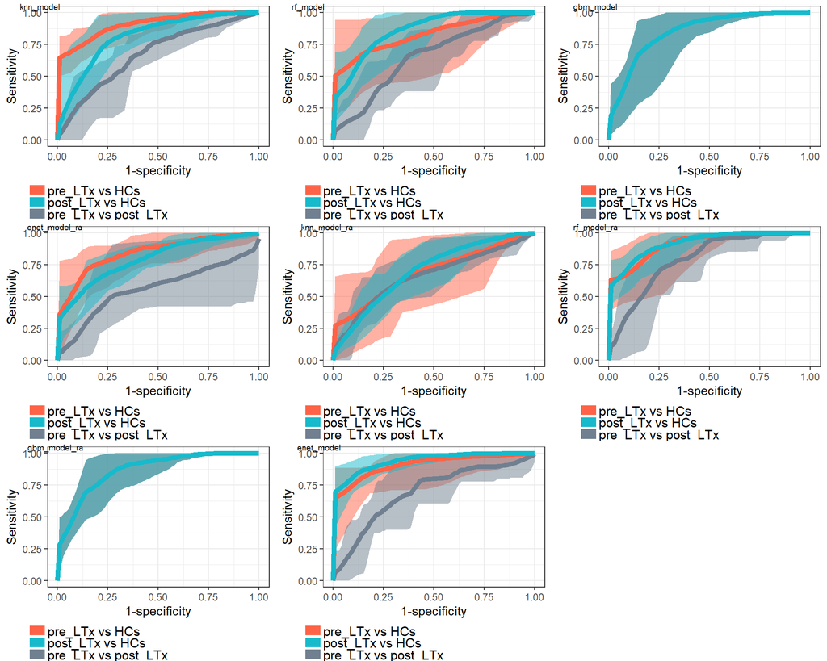

```r
rocs_list <- supplements_models$roc_cs
rocs_list[["enet_model"]] <- roc_cs

plot_list <- list()

for (model_name in names(rocs_list)) {
  plot_list[[model_name]] <- roc_curve_all_custom(rocs_list[[model_name]][c(1:3)],
                       Q="Q1_czech",
                       model_name=model_name)
}

ggarrange(plotlist = plot_list,labels = names(rocs_list),font.label = list(face="plain",size=7))
```

ROC - genus

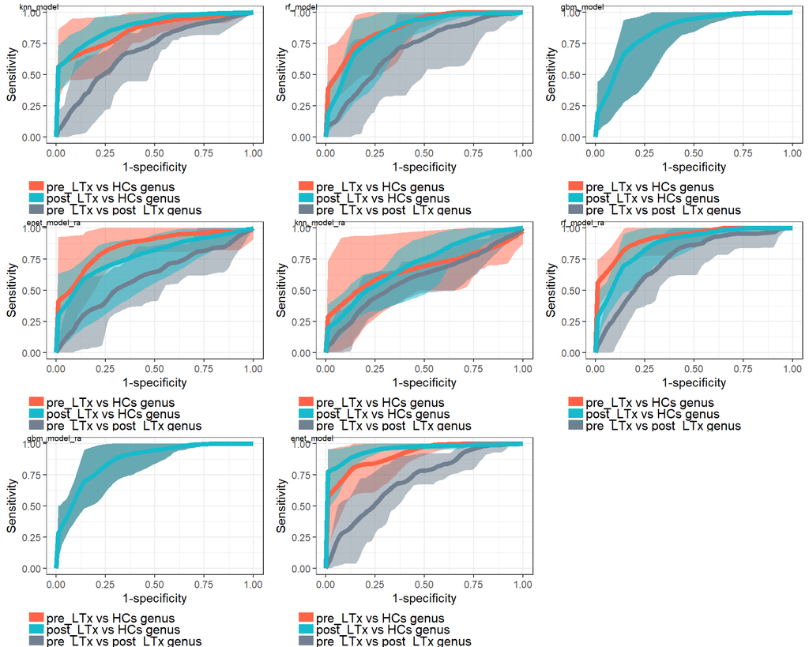

```r
plot_list <- list()

for (model_name in names(rocs_list)) {
  plot_list[[model_name]] <- roc_curve_all_custom(rocs_list[[model_name]][c(4:6)],
                       Q="Q1_czech",
                       model_name=model_name)
}

ggarrange(plotlist = plot_list,labels = names(rocs_list),font.label = list(face="plain",size=7))
```